# Projekt z zakresu analizy danych

Weronika Nadworska

## Cel badania

W Portugalii obowiązuje punktowy system oceniania od 0 do 20. Przekładając to na polską skalę ocen: ocena dopuszczająca to 10 punktów, dobra to 14-15 punktów, a celująca to 20 punktów. Uczniowie są oceniani na zakończenie każdego semestru (tutaj zmienne: `G1` oraz `G2`) i każdego roku szkolnego (tutaj zmienna `G3`). Do uzyskania promocji konieczne jest uzyskanie minimum 10 punktów.

[figure not shown]

Celem tego badania jest zidentyfikowanie oraz zbadanie w jaki sposób, czynniki takie jak: miejsce zamieszkania, uczęszczanie na zajęcia dodatkowe, czas poświęcany nauce czy dostęp do internetu, wpływają na punkty końcowe uczniów.

[figure not shown]

## Opis zbioru badawczego

Dane pochodzą z witryny [Kaggle](https://www.kaggle.com/datasets/dipam7/student-grade-prediction). Zawierają dane na temat 649 uczniów dwóch portugalskich szkół. Punkty uzyskane przez uczniów dotyczą języka portugalskiego.

Poniżej przedstawiono 10 początkowych wierszy zbioru badawczego.

| school | sex | age | address | famsize | Pstatus | Medu | Fedu | Mjob | Fjob | reason | guardian | traveltime | studytime | failures | schoolsup | famsup | paid | activities | nursery | higher | internet | romantic | famrel | freetime | goout | Dalc | Walc | health | absences | … |
| --- | --- | --- | --- | --- | --- | --- | --- | --- | --- | --- | --- | --- | --- | --- | --- | --- | --- | --- | --- | --- | --- | --- | --- | --- | --- | --- | --- | --- | --- | --- |
| GP | F | 18 | U | GT3 | A | 4 | 4 | at_home | teacher | course | mother | 2 | 2 | 0 | yes | no | no | no | yes | yes | no | no | 4 | 3 | 4 | 1 | 1 | 3 | 4 | … |
| GP | F | 17 | U | GT3 | T | 1 | 1 | at_home | other | course | father | 1 | 2 | 0 | no | yes | no | no | no | yes | yes | no | 5 | 3 | 3 | 1 | 1 | 3 | 2 | … |
| GP | F | 15 | U | LE3 | T | 1 | 1 | at_home | other | other | mother | 1 | 2 | 0 | yes | no | no | no | yes | yes | yes | no | 4 | 3 | 2 | 2 | 3 | 3 | 6 | … |
| GP | F | 15 | U | GT3 | T | 4 | 2 | health | services | home | mother | 1 | 3 | 0 | no | yes | no | yes | yes | yes | yes | yes | 3 | 2 | 2 | 1 | 1 | 5 | 0 | … |
| GP | F | 16 | U | GT3 | T | 3 | 3 | other | other | home | father | 1 | 2 | 0 | no | yes | no | no | yes | yes | no | no | 4 | 3 | 2 | 1 | 2 | 5 | 0 | … |
| GP | M | 16 | U | LE3 | T | 4 | 3 | services | other | reputation | mother | 1 | 2 | 0 | no | yes | no | yes | yes | yes | yes | no | 5 | 4 | 2 | 1 | 2 | 5 | 6 | … |
| GP | M | 16 | U | LE3 | T | 2 | 2 | other | other | home | mother | 1 | 2 | 0 | no | no | no | no | yes | yes | yes | no | 4 | 4 | 4 | 1 | 1 | 3 | 0 | … |
| GP | F | 17 | U | GT3 | A | 4 | 4 | other | teacher | home | mother | 2 | 2 | 0 | yes | yes | no | no | yes | yes | no | no | 4 | 1 | 4 | 1 | 1 | 1 | 2 | … |
| GP | M | 15 | U | LE3 | A | 3 | 2 | services | other | home | mother | 1 | 2 | 0 | no | yes | no | no | yes | yes | yes | no | 4 | 2 | 2 | 1 | 1 | 1 | 0 | … |
| GP | M | 15 | U | GT3 | T | 3 | 4 | other | other | home | mother | 1 | 2 | 0 | no | yes | no | yes | yes | yes | yes | no | 5 | 5 | 1 | 1 | 1 | 5 | 0 | … |

Dane składają się z 33 kolumn oraz 649 obserwacji.

Jak można zauważyć, dużo zmiennych jest kategorycznych, dlatego do dalszych badań ich typ został zmieniony na `factor`.

## Braki danych

|  | Liczba braków |
| --- | --- |
| school | 0 |
| sex | 0 |
| age | 0 |
| address | 0 |
| famsize | 0 |
| Pstatus | 0 |
| Medu | 0 |
| Fedu | 0 |
| Mjob | 0 |
| Fjob | 0 |
| reason | 0 |
| guardian | 0 |
| traveltime | 0 |
| studytime | 0 |
| failures | 0 |
| schoolsup | 0 |
| famsup | 0 |
| paid | 0 |
| activities | 0 |
| nursery | 0 |
| higher | 0 |
| internet | 0 |
| romantic | 0 |
| famrel | 0 |
| freetime | 0 |
| goout | 0 |
| Dalc | 0 |
| Walc | 0 |
| health | 0 |
| absences | 0 |
| G1 | 0 |
| G2 | 0 |
| G3 | 0 |
| adress | 0 |

W zbiorze nie występują braki danych.

## Statystyki opisowe

Podstawowe statystyki opisowe zmiennych numerycznych:

|  | age | absences | G1 | G2 | G3 |
| --- | --- | --- | --- | --- | --- |
| Min. | 15.00 | 0.000 | 0.0 | 0.00 | 0.00 |
| 1st Qu. | 16.00 | 0.000 | 10.0 | 10.00 | 10.00 |
| Median | 17.00 | 2.000 | 11.0 | 11.00 | 12.00 |
| Mean | 16.74 | 3.659 | 11.4 | 11.57 | 11.91 |
| 3rd Qu. | 18.00 | 6.000 | 13.0 | 13.00 | 14.00 |
| Max. | 22.00 | 32.000 | 19.0 | 19.00 | 19.00 |

Uczniowie biorący udział w badaniu są w wieku 15-22 lata. Patrząc na poszczególne punkty końcowe, możemy zauważyć, że są uczniowie, którzy uzyskali 0 punktów. Średnia punktów końcowych jest zbliżona do 12, co w portugalskiej skali ocen odpowiada polskiej “dwójce” lub “trójce”. Średnia punktów semestralnych wynosi 11 w obu semestrach, co również świadczy o dość słabych ocenach uczniów z języka portugalskiego.

Dla zmiennych kategorycznych prezentujemy ich możliwe poziomy, oraz liczby wystąpień każdego poziomu:

|  | school | sex | adress | famsize | Pstatus | Medu | Fedu | traveltime | Mjob | Fjob | reason | guardian | studytime | failures | schoolsup | famsup | paid | activities | nursery | higher | internet | romantic | famrel | freetime | goout | Dalc | Walc | health |
| --- | --- | --- | --- | --- | --- | --- | --- | --- | --- | --- | --- | --- | --- | --- | --- | --- | --- | --- | --- | --- | --- | --- | --- | --- | --- | --- | --- | --- |
|  | GP:423 | F:383 | R:197 | GT3:457 | A: 80 | 0: 6 | 0: 7 | Min. :1.000 | at_home :135 | at_home : 42 | course :285 | father:153 | 1:212 | 0:549 | no :581 | no :251 | no :610 | no :334 | no :128 | no : 69 | no :151 | no :410 | 1: 22 | 1: 45 | 1: 48 | 1:451 | 1:247 | 1: 90 |
|  | MS:226 | M:266 | U:452 | LE3:192 | T:569 | 1:143 | 1:174 | 1st Qu.:1.000 | health : 48 | health : 23 | home :149 | mother:455 | 2:305 | 1: 70 | yes: 68 | yes:398 | yes: 39 | yes:315 | yes:521 | yes:580 | yes:498 | yes:239 | 2: 29 | 2:107 | 2:145 | 2:121 | 2:150 | 2: 78 |
|  |  |  |  |  |  | 2:186 | 2:209 | Median :1.000 | other :258 | other :367 | other : 72 | other : 41 | 3: 97 | 2: 16 |  |  |  |  |  |  |  |  | 3:101 | 3:251 | 3:205 | 3: 43 | 3:120 | 3:124 |
|  |  |  |  |  |  | 3:139 | 3:131 | Mean :1.569 | services:136 | services:181 | reputation:143 |  | 4: 35 | 3: 14 |  |  |  |  |  |  |  |  | 4:317 | 4:178 | 4:141 | 4: 17 | 4: 87 | 4:108 |
|  |  |  |  |  |  | 4:175 | 4:128 | 3rd Qu.:2.000 | teacher : 72 | teacher : 36 |  |  |  |  |  |  |  |  |  |  |  |  | 5:180 | 5: 68 | 5:110 | 5: 17 | 5: 45 | 5:249 |
|  |  |  |  |  |  |  |  | Max. :4.000 |  |  |  |  |  |  |  |  |  |  |  |  |  |  |  |  |  |  |  |  |

Zmienne `Mjob` oraz `Fjob` nie będą przedmiotem badań, ponieważ często występuje w nich poziom `other` (inne), co może nie mieć znaczącego przełożenia na punkty końcowe uczniów w rzeczywistości. Zmienne `reason` oraz `guardian` ze względu na trudność w interpretacji wyników, nie będą brane pod uwagę w badaniach.

Badać będziemy czy i jak poszczególne zmienne działają na zmienną `G3` (punkty końcowe) z przedmiotu.

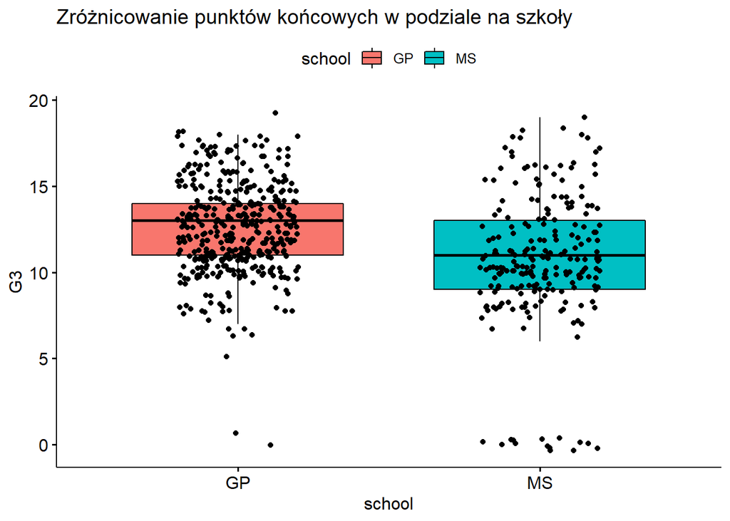

Zróżnicowanie uzyskanych punktów w podziale na szkoły:

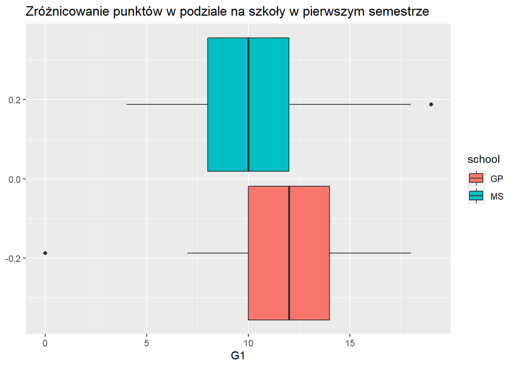

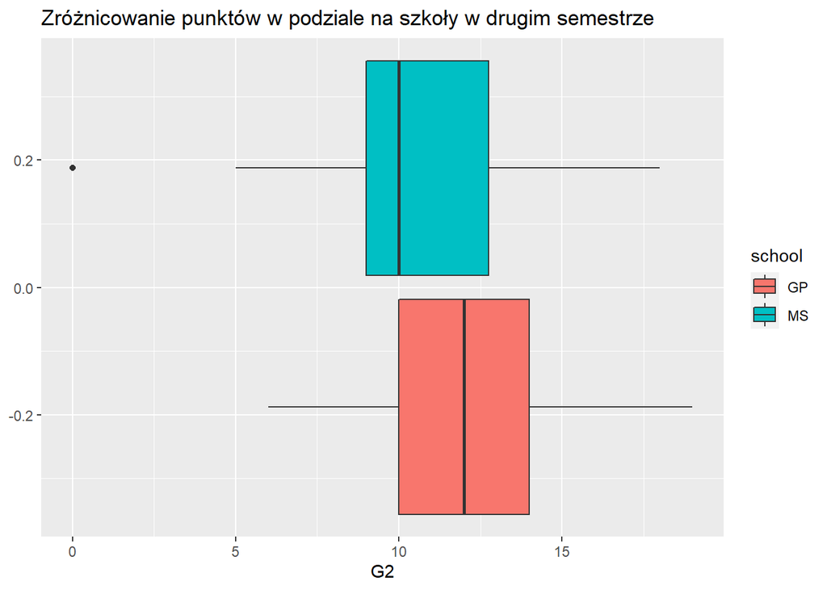

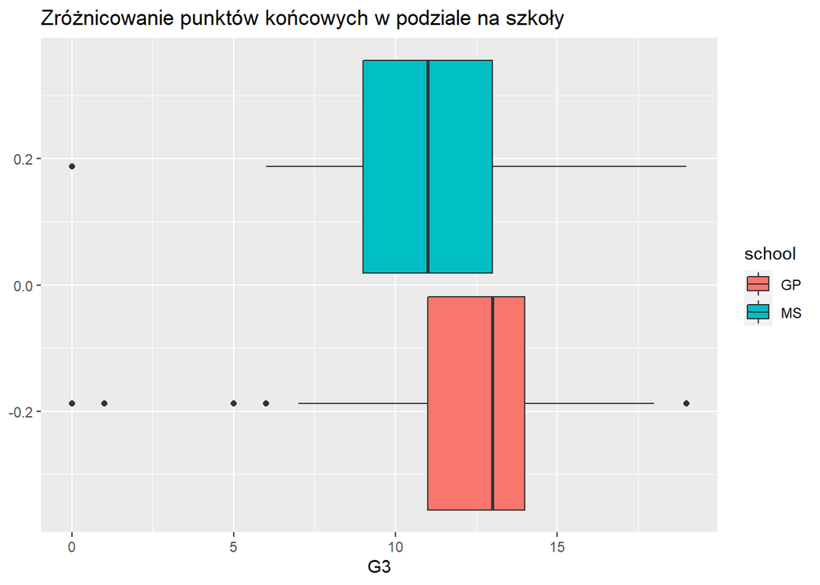

Zauważyć można, że mediana punktów w każdym z semestrów oraz punktów końcowych w szkole Mousinho da Silveira jest niższa niż w szkole Gabriel Pereira.

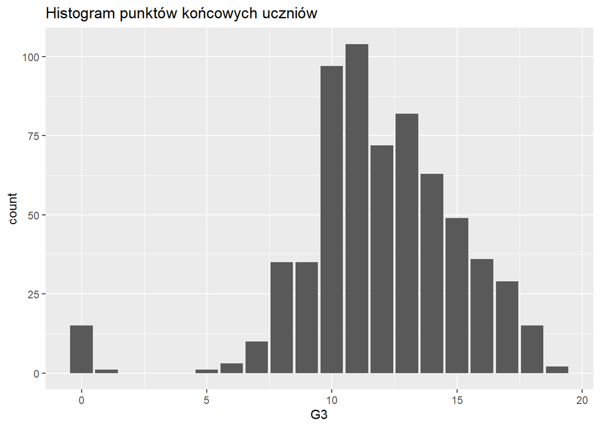

Uczniowie zwykle uzyskiwali punkty na koniec roku z zakresu 10-13 punktów, co odpowiada polskim ocenom z przedziału 2-3.

```
## [1] 100
```

Stu uczniów uzyskało liczbę punktów mniejszą niż 10, co oznacza, że nie uzyskali oni promocji do następnej klasy. W porównaniu z całą grupą 649 uczniów, stanowią oni 15,4%. Niestety nikomu nie udało się dostać 20 punktów, co odpowiadałoby polskiej ocenie “6”.

Wykres poniżej przedstawia średnią punktów w danej grupie wraz z jej przedziałem ufności.

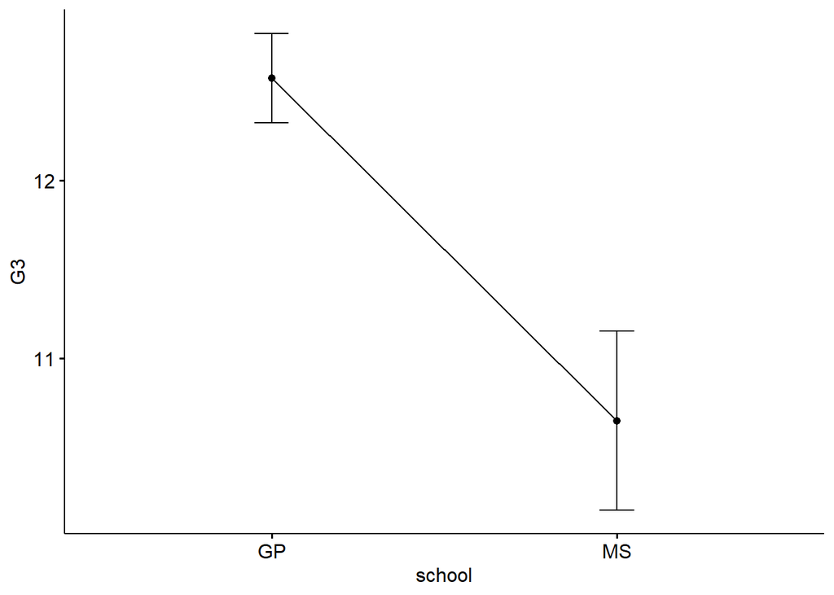

Widzimy, że średnia punktów końcowych w szkole Gabriel Pereira jest nieco wyższa niż w szkole Mousinho da Silveira.

## Hipotezy

Weryfikowane będą następujące hipotezy:

- Niezależność płci ucznia i liczby uzyskanych punktów końcowych
- Niezależność wieku ucznia i liczby uzyskanych punktów końcowych
- Niezależność typu adresu zamieszkania ucznia i liczby uzyskanych punktów końcowych
- Niezależność rozmiaru rodziny i liczby uzyskanych punktów końcowych
- Niezależność stanu konkubinatu rodziców i liczby uzyskanych punktów końcowych ucznia
- Niezależność poziomu edukacji matki i liczby uzyskanych punktów końcowych
- Niezależność poziomu edukacji ojca i liczby uzyskanych punktów końcowych
- Niezależność czasu dojazdu do szkoły i liczby uzyskanych punktów końcowych
- Średni czas dojazdu ucznia do szkoły jest istotnie dłuższy niż 30 minut
- Niezależność tygodniowego czasu nauki i liczby uzyskanych punktów końcowych
- Niezależność ilości niezdanych klas ucznia (liczby niezdanych razy) i liczby uzyskanych punktów końcowych
- Niezależność dodatkowego wsparcia edukacyjnego i liczby uzyskanych punktów końcowych
- Niezależność rodzinnego wsparcia edukacyjnego i liczby uzyskanych punktów końcowych
- Niezależność dodatkowo płatnych zajęć z przedmiotu (język portugalski) i liczby uzyskanych punktów końcowych
- Niezależność uczęszczania na zajęcia pozalekcyjne i liczby uzyskanych punktów końcowych
- Niezależność uczęszczania do przedszkola w dzieciństwie i liczby uzyskanych punktów końcowych
- Niezależność chęci kontynuowania edukacji i liczby uzyskanych punktów końcowych
- Niezależność dostępu ucznia do internetu w domu i liczby uzyskanych punktów końcowych
- Niezależność bycia w związku przez ucznia i liczby uzyskanych punktów końcowych
- Niezależność jakości relacji rodzinnych i liczby uzyskanych punktów końcowych
- Niezależność ilości czasu wolnego po szkole i liczby uzyskanych punktów końcowych
- Niezależność częstotliwości spotykania się ze znajomymi i liczby uzyskanych punktów końcowych
- Niezależność ilości spożywanego alkoholu w dni robocze i liczby uzyskanych punktów końcowych
- Niezależność ilości spożywanego alkoholu w weekendy i liczby uzyskanych punktów końcowych
- Niezależność obecnego stanu zdrowia i liczby uzyskanych punktów końcowych
- Niezależność ilości nieobecności w szkole i liczby uzyskanych punktów końcowych

## Weryfikacja hipotez

Do weryfikacji postawionych hipotez posłuży test $\chi^2$ o hipotezach:

$H_0$: Dystrybuantą badanej cechy jest $F_0$ / Cechy są niezależne (brak wpływu cechy na wyniki)

$H_1$: Dystrybuantą badanej cechy nie jest $F_0$ / Cechy nie są niezależne (wpływ cechy na wyniki)

Przechodzimy do weryfikacji hipotez.

$H_0$: Niezależność wieku ucznia oraz liczby uzyskanych punktów końcowych.

$H_1$: Brak niezależności wieku ucznia oraz liczby uzyskanych punktów końcowych.

Najpierw badamy normalność:

```
##
##  Shapiro-Wilk normality test
##
## data:  dane$age
## W = 0.91559, p-value < 2.2e-16
```

```
##
##  Asymptotic one-sample Kolmogorov-Smirnov test
##
## data:  dane$age
## D = 0.17468, p-value < 2.2e-16
## alternative hypothesis: two-sided
```

Na poziomie istotności 0,05 odrzucamy $H_0$ o normalności badanej cechy. Nie możemy stosować testu t- Studenta, ale możemy test Wilcox’ona.

$H_0$: Cechy maja jednakowe rozkłady.

$H_1$: Cechy mają różne rozkłady.

```
##
##  Wilcoxon signed rank test with continuity correction
##
## data:  dane$age
## V = 210925, p-value < 2.2e-16
## alternative hypothesis: true location is not equal to 0
```

$H_0$: Niezależność płci oraz liczby uzyskanych punktów końcowych.

$H_1$: Brak niezależności płci ucznia oraz liczby uzyskanych przez niego punktów końcowych.

```
##
##  Pearson's Chi-squared test
##
## data:  tab
## X-squared = 21.91, df = 16, p-value = 0.1461
```

Nie ma podstaw do odrzucenia hipotezy o niezależności cech. Zatem nie występuje zależność pomiędzy płcią, a uzyskanymi punktami końcowymi z przedmiotu.

Przeprowadzono również test Wilcox’ona, który odrzuca hipotezę o tym samym rozkładzie dla obu cech.

```
##
##  Wilcoxon rank sum test with continuity correction
##
## data:  dane$G3 by dane$sex
## W = 58917, p-value = 0.0006317
## alternative hypothesis: true location shift is not equal to 0
```

$H_0$: Niezależność typu adresu zamieszkania ucznia oraz liczby uzyskanych punktów końcowych.

$H_1$: Brak niezależności cech.

```
##
##  Pearson's Chi-squared test
##
## data:  tab
## X-squared = 36.59, df = 16, p-value = 0.002394
```

Odrzucamy hipotezę zerową na korzyść alternatywnej. Zatem istnieje zależność między typem adresu zamieszkania ucznia oraz liczbą uzyskanych przez niego punktów końcowych.

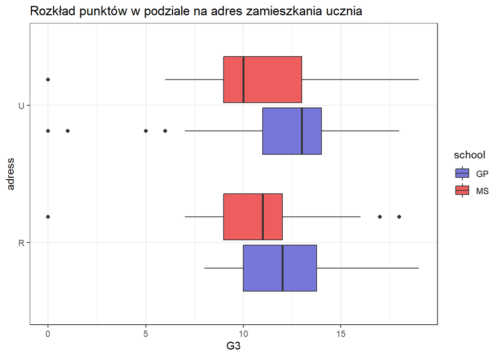

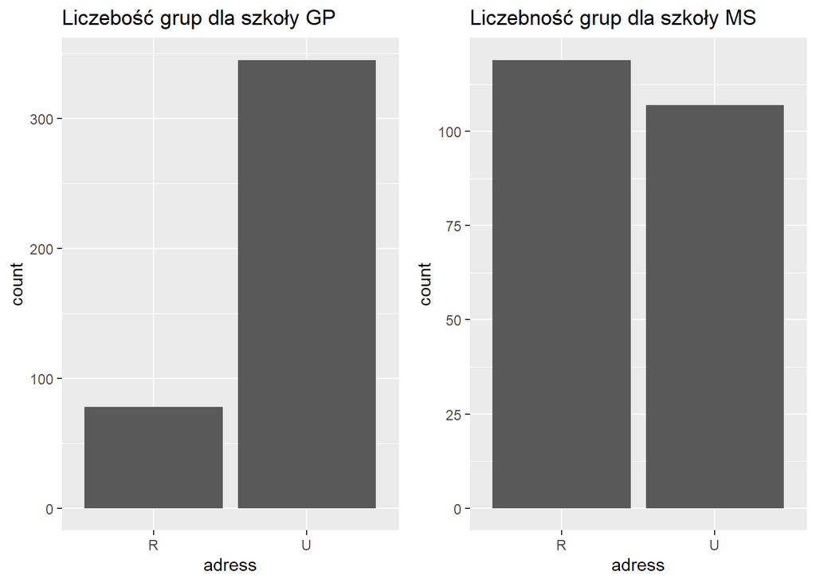

Do szkoły Gabriel Pereira uczęszczają głównie uczniowie zamieszkujący miasta. W tej samej szkole zauważalna jest wyższa mediana uzyskiwanych przez uczniów punktów. Możliwa jest zatem wyższa ilość punktów dla uczniów mieszkających w mieście.

$H_0$: Niezależność czasu dojazdu ucznia do szkoły oraz liczby uzyskanych punktów końcowych.

$H_1$: Brak niezależności czasu dojazdu ucznia do szkoły oraz liczby uzyskanych punktów końcowych.

```
##
##  Pearson's Chi-squared test
##
## data:  tab
## X-squared = 55.198, df = 48, p-value = 0.2212
```

Nie ma podstaw do odrzucenia $H_0$. Zatem cechy te są niezależne.

$H_0$: Średni czas dojazdu ucznia do szkoły jest istotnie dłuższy niż 30 minut.

$H_1$: Średni czas dojazdu ucznia do szkoły nie jest istotnie dłuższy niż 30 minut.

```
## [1] -11.74808
```

```
## [1] 1.644854
```

$H_0$: Niezależność wielkości rodziny oraz liczby uzyskanych punktów końcowych.

$H_1$: Brak niezależności wielkości rodziny oraz liczby uzyskanych punktów końcowych.

```
##
##  Pearson's Chi-squared test
##
## data:  tab
## X-squared = 11.547, df = 16, p-value = 0.7745
```

Nie ma podstaw do odrzucenia $H_0$. Zatem cechy są niezależne.

$H_0$: Niezależność stanu konkubinatu rodziców oraz liczby uzyskanych punktów końcowych.

$H_1$: Brak niezależności stanu konkubinatu rodziców oraz liczby uzyskanych punktów końcowych.

```
##
##  Pearson's Chi-squared test
##
## data:  tab
## X-squared = 3.9539, df = 16, p-value = 0.999
```

Nie ma podstaw do odrzucenia $H_0$. Zatem cechy są niezależne.

$H_0$: Niezależność poziomu edukacji matki oraz liczby uzyskanych punktów końcowych ucznia.

$H_1$: Brak niezależności poziomu edukacji matki oraz liczby uzyskanych punktów końcowych ucznia.

```
##
##  Pearson's Chi-squared test
##
## data:  tab1
## X-squared = 116.85, df = 64, p-value = 6.147e-05
```

Odrzucamy $H_0$ o niezależności cech. Zatem cechy są zależne.

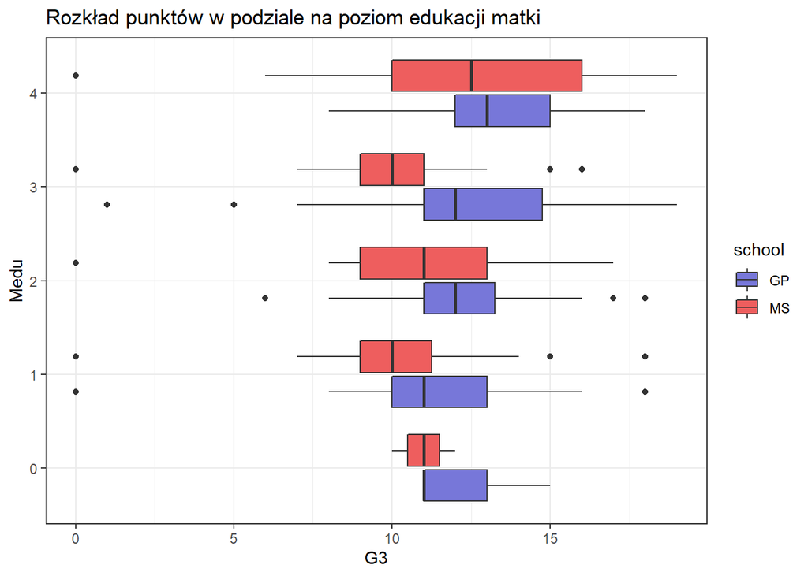

Zauważyć można, że zakres zdobywanych punktów wzrasta wraz z wyższym poziomem edukacji matki. Mediana punktów dla szkoły Gabriel Pereira wzrasta wraz ze zwiększajacym się poziomem edukacji matki. Dla szkoły Mousinho da Silveira mediana punktów nie rośnie równomiernie, jednak jest najwyższa, gdy poziom edukacji matki osiąga poziom 4 (najwyższy).

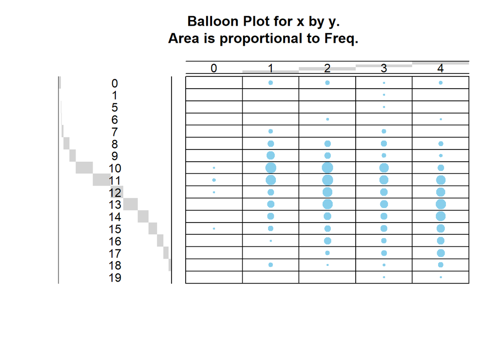

Dla poziomu edukacji matki nr 1 (wykształcenie podstawowe), uczniowie zwykle uzyskiwali punkty w zakresie 10-11. Dla poziomu edukacji nr 2 (ukończona 5-9. klasa) oraz 3 (wykształcenie średnie) jest podobnie. Dla poziomu edukacji nr 4 (wykształcenie wyższe) zakres punktów obejmuje wartości 13-14. 11 to najczęstsza wartość punktów, którą uzyskują uczniowie, co w polskiej skali ocen odpowiada ocenie na granicy 2-3.

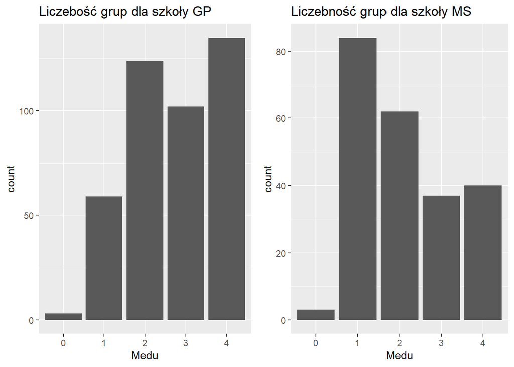

W szkole Gabriel Pereira matki uczniów mają głównie wyższe wykszałcenie, co wiąże się z wnioskami dotyczącymi wykresu boxplot uzyskanego wyżej - matki uczniów mają wyższe wykszatałcenie, a mediana punktów uczniów w tej szkole rośnie wraz ze wzrostem poziomu edukacji matki.

$H_0$: Niezależność poziomu edukacji ojca oraz liczby uzyskanych punktów końcowych ucznia.

$H_1$: Brak niezależności poziomu edukacji ojca oraz liczby uzyskanych punktów końcowych ucznia.

```
##
##  Pearson's Chi-squared test
##
## data:  tab2
## X-squared = 107.86, df = 64, p-value = 0.0005011
```

Odrzucamy $H_0$ o niezależności cech na korzyść $H_1$. Zatem cechy są zależne.

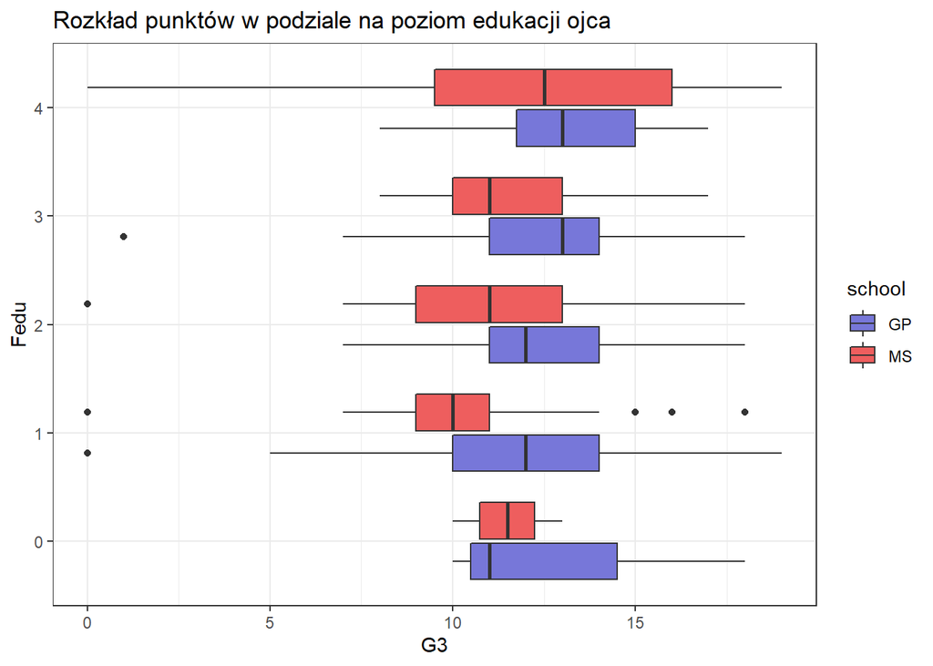

Zauważyć można, że mediana punktów dla szkoły Gabriel Pereira wzrasta wraz z poziomem edukacji ojca. Dla szkoły Mousinho da Silveira mediana punktów, podobnie jak w przypadku poziomu edukacji matki, jest najwyższa gdy poziom edukacji ojca osiąga poziom 4 (najwyższy). Jednak wysokie wartości uzyskiwanych punktów mają miejsce zarówno dla poziomu edukacji nr 1, jak i dla poziomu 4.

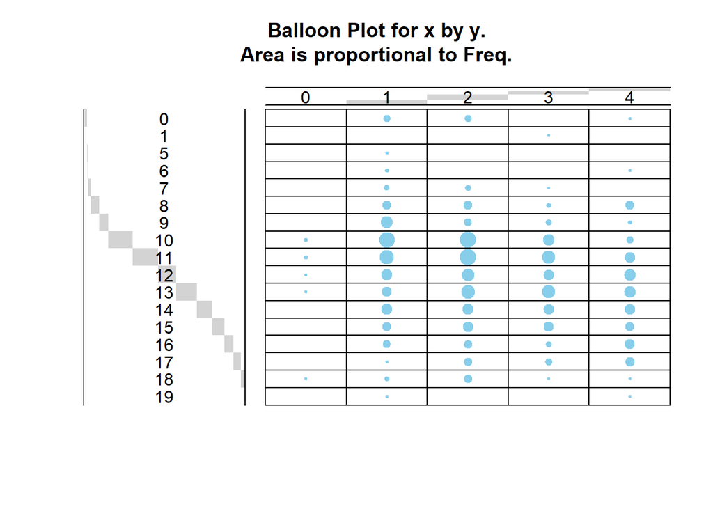

Dla poziomu edukacji ojca nr 1 (wykształcenie podstawowe), uczniowie zwykle uzyskiwali punkty w zakresie 10-11. Dla poziomu edukacji nr 2 (ukończona 5-9. klasa) jest podobnie. Dla poziomu edukacji nr 3 (wykształcenie średnie) jest to zakres 11-13. Dla poziomu edukacji nr 4 (wykształcenie wyższe) zakres punktów obejmuje wartości 12-13. 11 to najczęstsza wartość punktów, którą uzyskują uczniowie, co w polskiej skali ocen odpowiada ocenie na granicy 2-3.

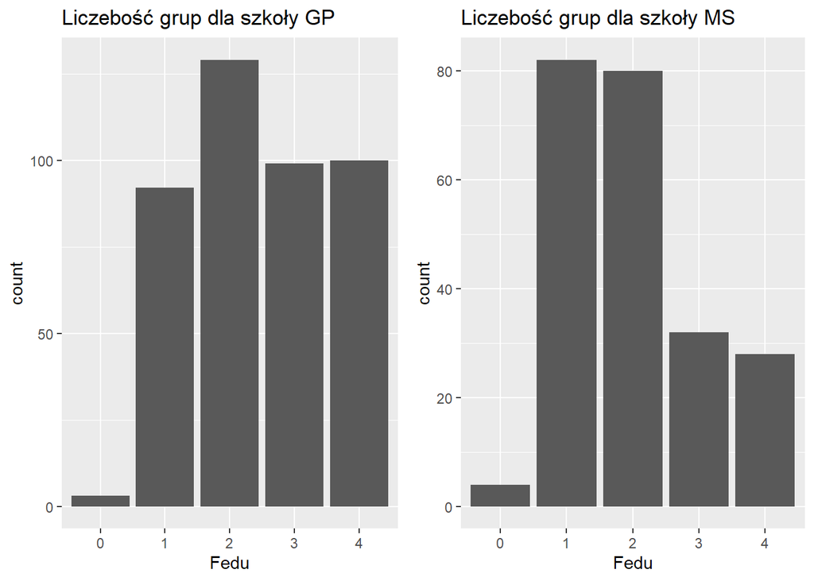

Liczebność ojców na poziomie edukacji 3 i 4 (wykształcenie średnie oraz wyższe) w szkole Gabriel Pereira jest wyższa, co koresponduje z wyższą medianą punktów w tej szkole.

$H_0$: Niezależność tygodniowej ilości nauki oraz liczby uzyskanych punktów końcowych.

$H_1$: Brak niezależności tygodniowej ilości nauki oraz liczby uzyskanych punktów końcowych.

```
##
##  Pearson's Chi-squared test
##
## data:  tab
## X-squared = 92.707, df = 48, p-value = 0.0001144
```

Odrzucamy $H_0$ na korzyść $H_1$. Zatem występuje zależność między cechami.

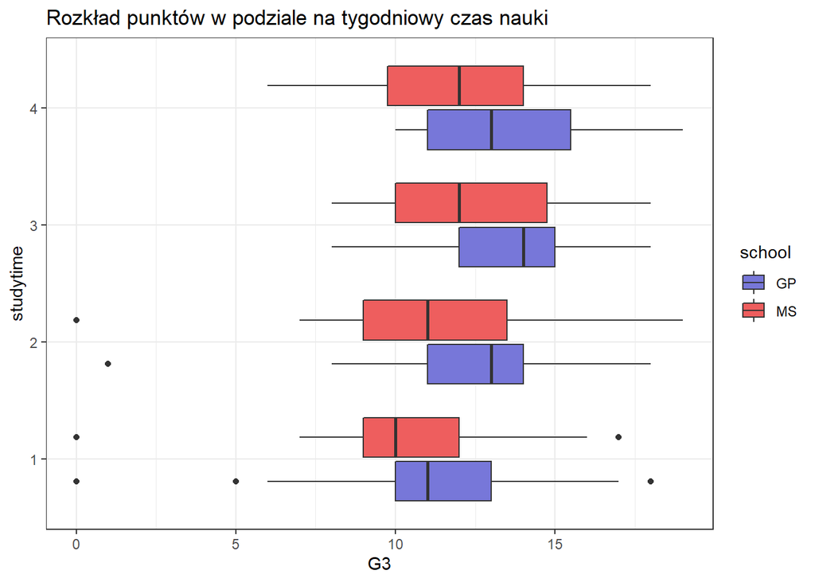

Zauważyć można, że dla szkoły Mousinho da Silveira, wraz ze wzrostem czasu poświęcanego nauce w ciągu tygodnia, rozszerza się zakres punktów o punkty wyższe oraz wyższa jest mediana uzyskiwanych przez uczniów punktów. W szkole Gabriel Pereira również można zaobserwować podobne tendencje, jednak mediana punktów dla poziomu ilości nauki równemu 4 (więcej niż 10 godzin) jest niższa niż na przykład dla poziomu 3.

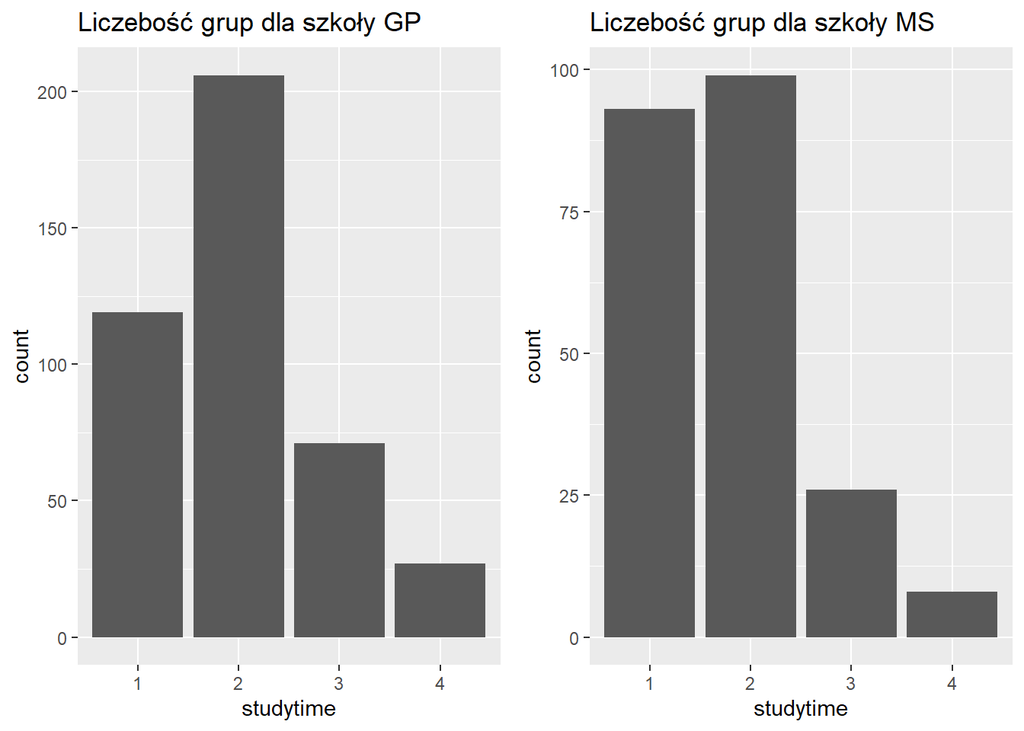

Liczebności uczniów w obu szkołach w każdej z grup są na podobnych poziomach.

$H_0$: Niezależność dodatkowego wsparcia edukacyjnego oraz liczby uzyskanych punktów końcowych.

$H_1$: Brak niezależności dodatkowego wsparcia edukacyjnego oraz liczby uzyskanych punktów końcowych.

```
##
##  Pearson's Chi-squared test
##
## data:  tab
## X-squared = 24.303, df = 16, p-value = 0.0831
```

Nie ma podstaw do odrzucenia $H_0$ - nie istnieje zależność między cechami.

$H_0$: Nieależność uczęszczania w dzieciństwie do przedszkola oraz liczby uzyskanych punktów końcowych.

$H_1$: Brak nieależności uczęszczania w dzieciństwie do przedszkola oraz liczby uzyskanych punktów końcowych.

```
##
##  Pearson's Chi-squared test
##
## data:  tab
## X-squared = 16.16, df = 16, p-value = 0.4419
```

Nie ma podstaw do odrzucenia $H_0$ o niezależności cech.

$H_0$: Niezależność dostępu do internetu oraz liczby uzyskanych punktów końcowych.

$H_1$: Brak niezależności dostępu do internetu oraz liczby uzyskanych punktów końcowych.

```
##
##  Pearson's Chi-squared test
##
## data:  tab
## X-squared = 24.474, df = 16, p-value = 0.07965
```

Nie ma podstaw do odrzucenia $H_0$ - cechy są niezależne.

$H_0$: Niezależność bycia w związku oraz liczby uzyskanych punktów końcowych.

$H_1$: Brak niezależności bycia w związku oraz liczby uzyskanych punktów końcowych.

```
##
##  Pearson's Chi-squared test
##
## data:  tab
## X-squared = 17.003, df = 16, p-value = 0.3854
```

Nie ma podstaw do odrzucenia $H_0$. Zatem cechy są niezależne.

$H_0$: Niezależność jakości relacji w rodzinie oraz liczby uzyskanych punktów końcowych.

$H_1$: Brak niezależności jakości relacji w rodzinie oraz liczby uzyskanych punktów końcowych.

```
##
##  Pearson's Chi-squared test
##
## data:  tab
## X-squared = 73.643, df = 64, p-value = 0.1918
```

Nie ma pdostaw do odrzucenia $H_0$ o niezależnosci cech.

$H_0$: Niezależność ilości czasu wolnego po szkole oraz liczby uzyskanych punktów końcowych.

$H_1$: Brak niezależności ilości czasu wolnego po szkole oraz liczby uzyskanych punktów końcowych.

```
##
##  Pearson's Chi-squared test
##
## data:  tab
## X-squared = 86.13, df = 64, p-value = 0.03401
```

Odrzucamy $H_0$ o niezależności cech. Zatem istnieje zależność między cechami.

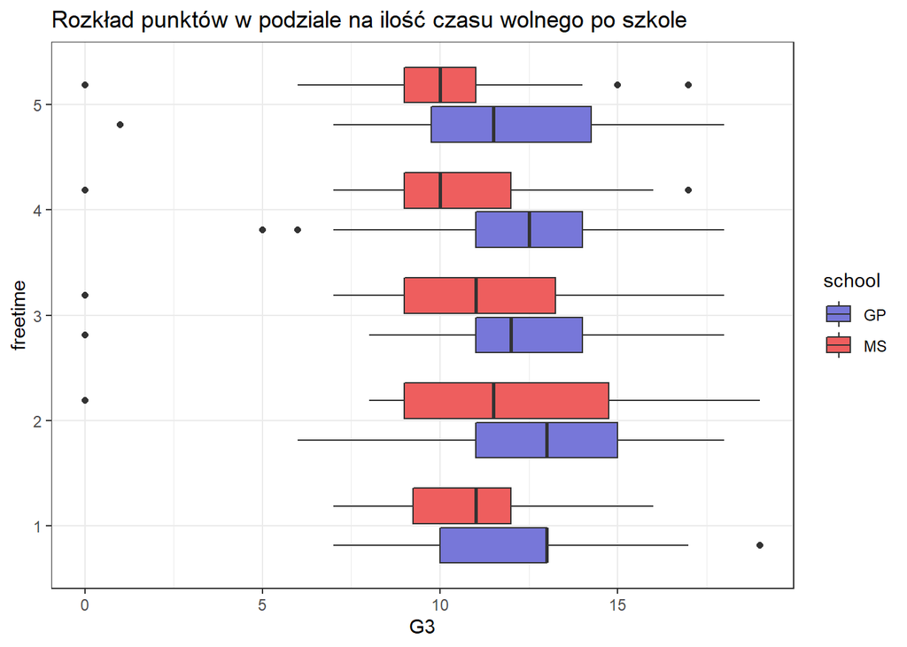

Na powyższym wykresie boxplot zauważyć można, że mediany punktów dla niższych poziomów są nieco wyższe niż dla wyższych poziomów w obu szkołach. Zatem można wywnioskować, że uczniowie o czasie wolnym na poziome 1 czy 2 (bardzo mało oraz mało czasu wolnego) uzyskiwali więcej punktów od uczniów, którzy czasu wolnego mają więcej.

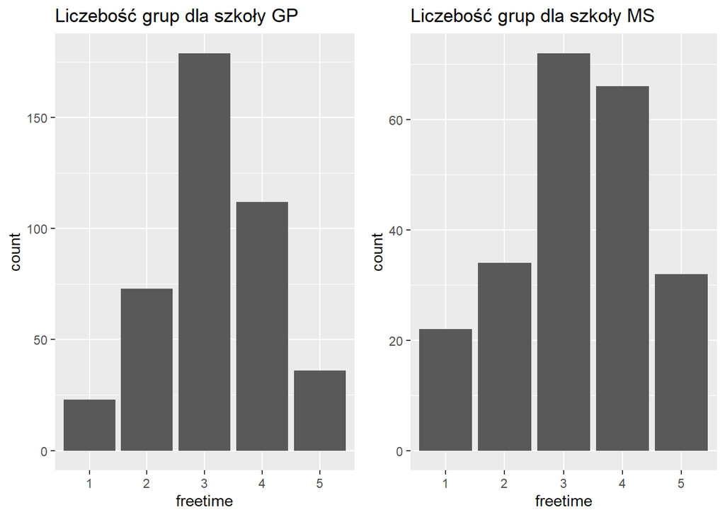

Widzimy, że przeciętny uczeń jest w grupie, gdzie czas wolny jest na poziomie 3 (średnia ilość czasu wolnego).

$H_0$: Niezależność częstości spotykania się ze znajomymi oraz liczby uzyskanych punktów końcowych.

$H_1$: Brak niezależności częstości spotykania się ze znajomymi oraz liczby uzyskanych punktów końcowych.

```
##
##  Pearson's Chi-squared test
##
## data:  tab
## X-squared = 105.22, df = 64, p-value = 0.000897
```

Odrzucamy $H_0$ o niezależności cech. Zatem cechy są zależne.

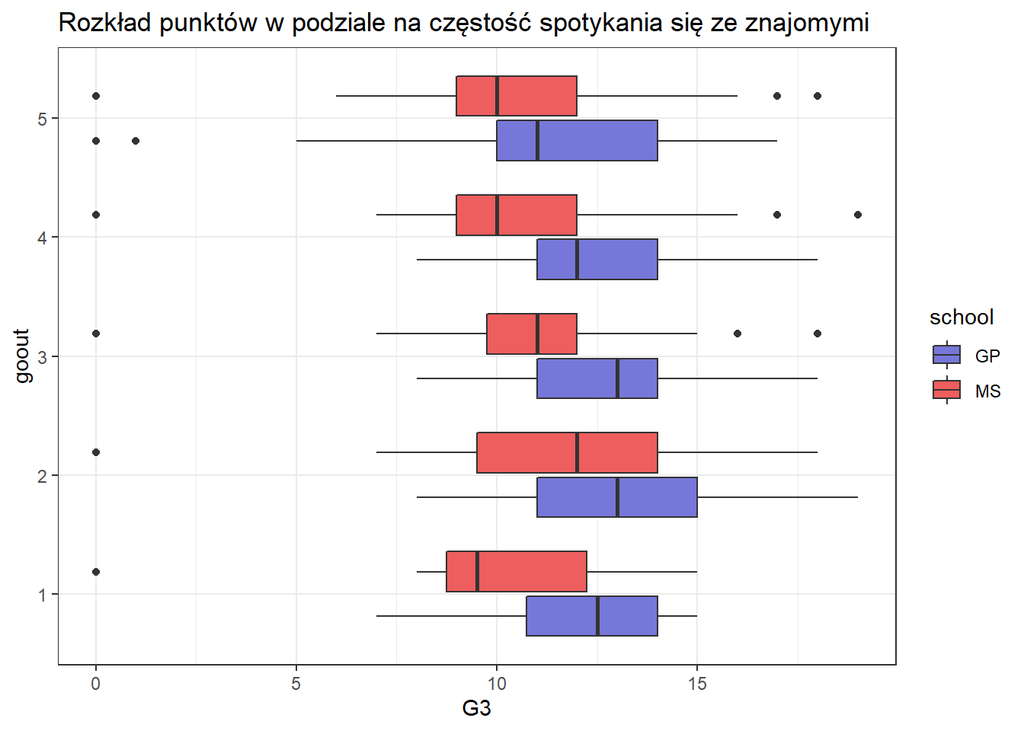

W szkole Gabriel Pereira rzadkie spotykanie się ze znajomymi skutkuje wyższymi ilościami uzyskiwanych punktów (wyższa mediana punktów w grupie 1, 2, 3) oraz zakres obejmuje wyższe punkty. W szkole Mousinho da Silveira jest podobnie, choć dla grupy na poziomie 1 (bardzo mało czasu na spotykanie się ze znajomymi) mediana punktów jest niższa niż 10, co jest poniżej granicy zdawalności.

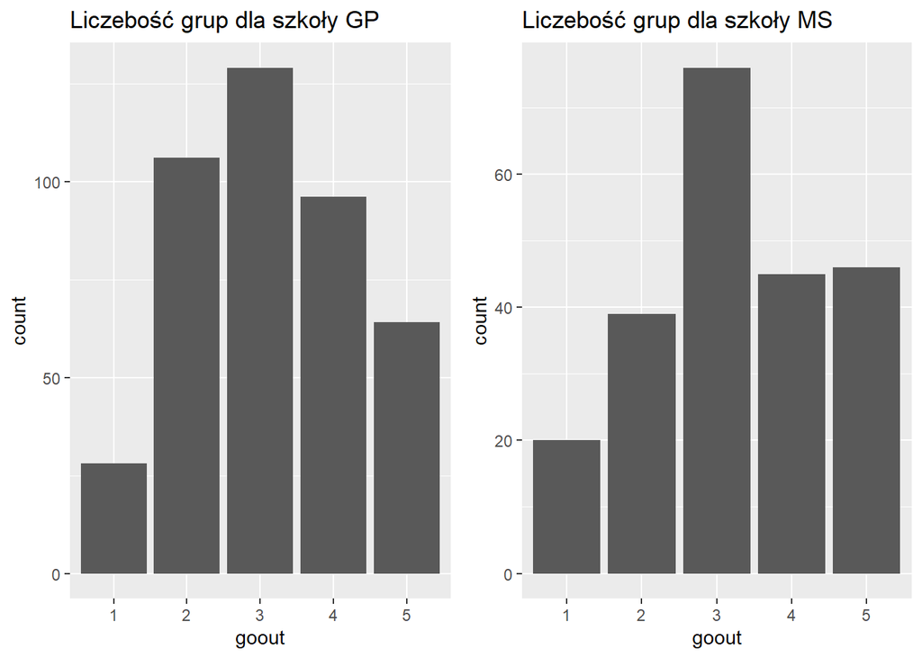

Liczebności w każdej z grup w obu szkołach są na podobnym poziomie. Najwięcej uczniów na spotykanie się ze znajomymi poświęca średnią ilość czasu.

$H_0$: Niezależność picia alkoholu w dni robocze oraz liczby uzyskanych punktów końcowych.

$H_1$: Brak niezależności picia alkoholu w dni robocze oraz liczby uzyskanych punktów końcowych.

```
##
##  Pearson's Chi-squared test
##
## data:  tab
## X-squared = 164.98, df = 64, p-value = 7.388e-11
```

Odrzucamy hipotezę o niezależności cech. Zatem istnieje zależność pomiędzy cechami.

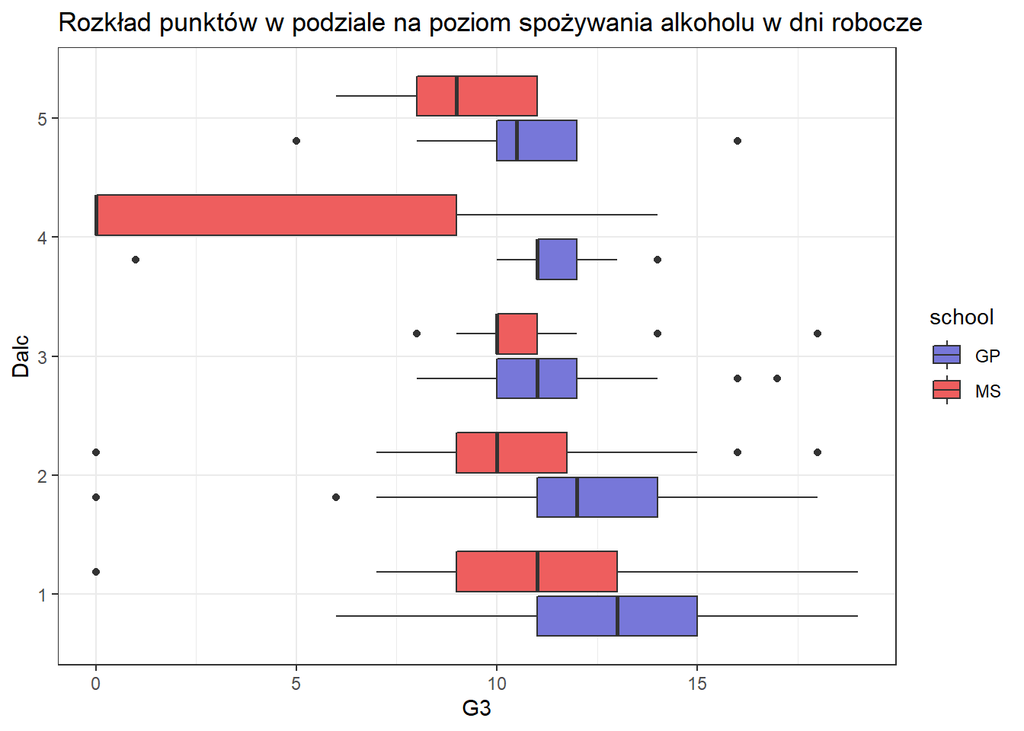

Na wykresie boxplot zauważyć można, że uczniowie, w których domach spożywa się duże ilości alkoholu uzyskują dużo niższe punkty.

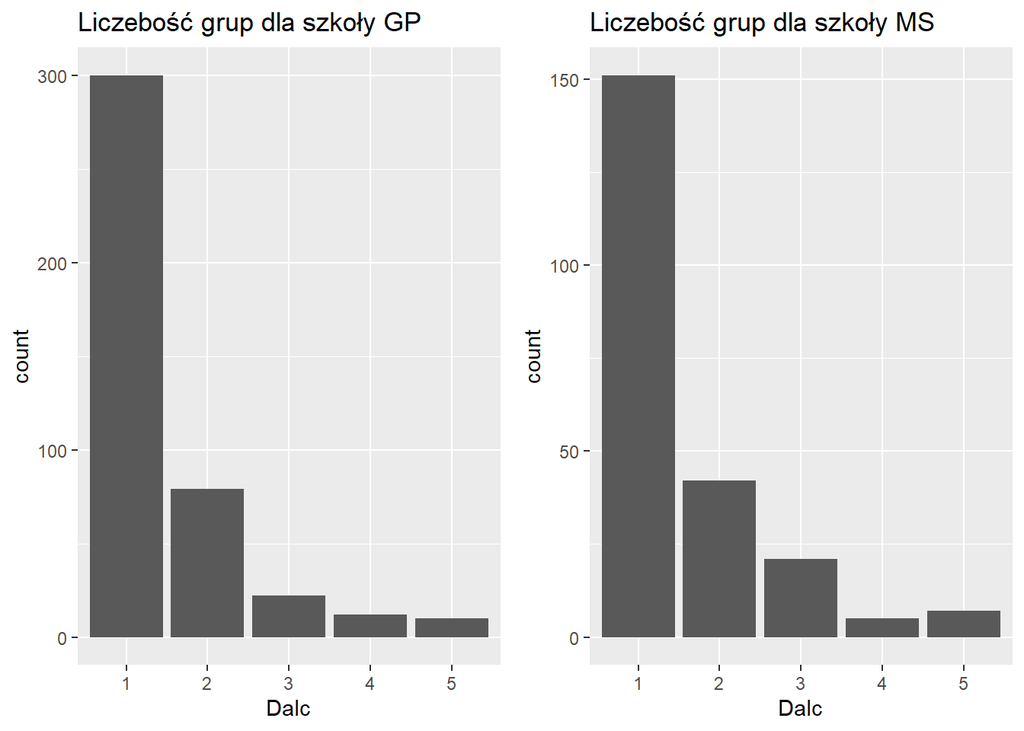

(Na szczęście) liczebności na poziomach 3-5 są małe. Zatem w domach uczniów spożywa się bardzo mało oraz mało alkoholu w dni robocze.

$H_0$: Niezależność picia alkoholu w weekendy oraz liczby uzyskanych punktów końcowych.

$H_1$: Brak niezależności picia alkoholu w weekendy oraz liczby uzyskanych punktów końcowych.

```
##
##  Pearson's Chi-squared test
##
## data:  tab
## X-squared = 102.26, df = 64, p-value = 0.001685
```

Odrzucamy hipotezę o niezależności cech. Zatem zależność między cechami występuje.

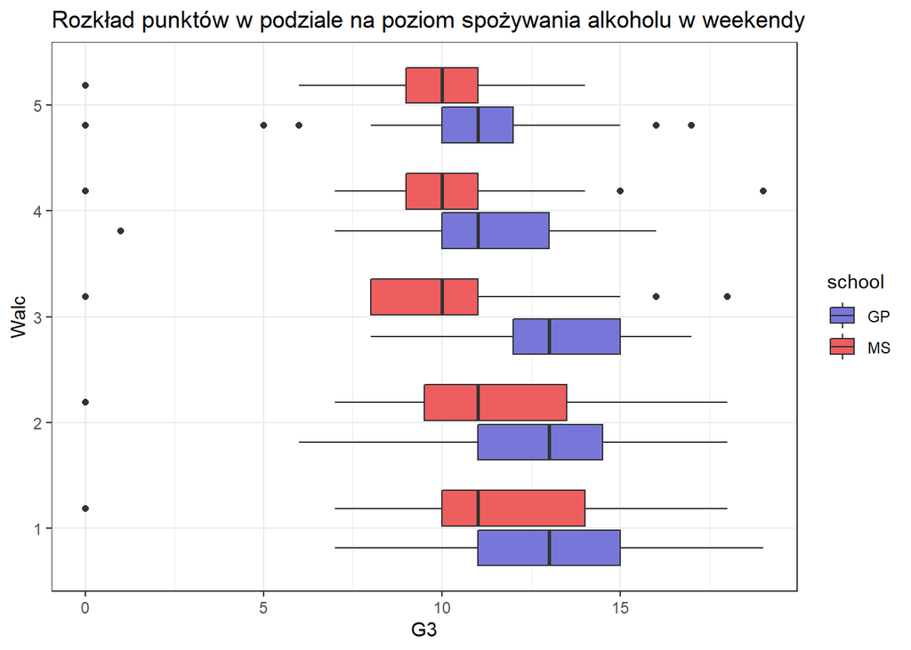

Dla obu szkół zauważyć można te same zależności - im więcej spożywa się alkoholu w weekendy, tym mediana punktów uczniów jest niższa.

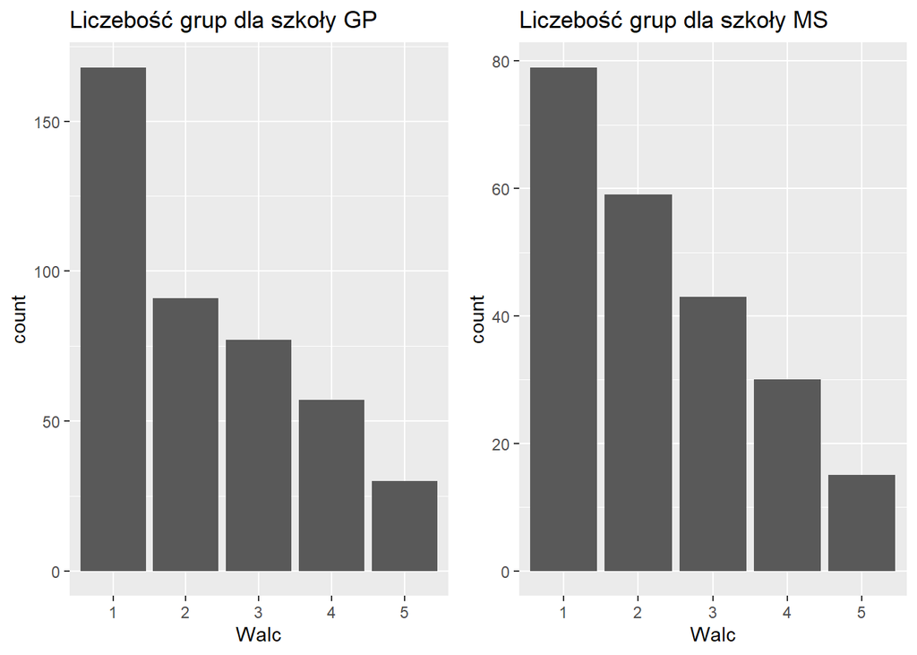

Tutaj liczebności spożywania alkoholu w weekendy są wyższe niż dla spożywania alkoholu w dni robocze dla uczniow w obu szkołach. Jednak nadal głównie są to uczniowie, w których domach alkohol w weekendy spożywa się na niskim poziomie.

$H_0$: Niezależność stanu zdrowia oraz liczby uzyskanych punktów końcowych.

$H_1$: Brak niezależności stanu zdrowia oraz liczby uzyskanych punktów końcowych.

```
##
##  Pearson's Chi-squared test
##
## data:  tab
## X-squared = 76.694, df = 64, p-value = 0.1328
```

Nie ma podstaw do odrzucenia $H_0$ o niezależności cech.

$H_0$: Niezależność ilości nieobecności oraz liczby uzyskanych punktów końcowych.

$H_1$: Brak niezależności ilości nieobecności oraz liczby uzyskanych punktów końcowych.

Najpierw badamy normalność:

```
##
##  Shapiro-Wilk normality test
##
## data:  dane$absences
## W = 0.77174, p-value < 2.2e-16
```

```
##
##  Asymptotic one-sample Kolmogorov-Smirnov test
##
## data:  dane$absences
## D = 0.21519, p-value < 2.2e-16
## alternative hypothesis: two-sided
```

Na poziomie istotności 0,05 odrzucamy $H_0$ o normalności badanej cechy. Możemy stosować test Wilcox’ona.

$H_0$: Cechy mają jednakowe rozkłady.

$H_1$: Cechy mają różne rozkłady.

```
##
##  Wilcoxon signed rank test with continuity correction
##
## data:  dane$absences
## V = 82215, p-value < 2.2e-16
## alternative hypothesis: true location is not equal to 0
```

Odrzucamy $H_0$ o jednakowych rozkładach badanych cech. Zatem nie istnieje zależność pomiędzy ilością nieobecności ucznia, a ilością punktów, które otrzymuje na koniec semestru.

$H_0$: Niezależność chęci kontynuowania edukacji przez ucznia oraz liczby uzyskanych punktów końcowych.

$H_1$: Brak niezależności chęci kontynuowania edukacji przez ucznia oraz liczby uzyskanych punktów końcowych.

```
##
##  Pearson's Chi-squared test
##
## data:  tab
## X-squared = 106.7, df = 16, p-value = 1.898e-15
```

Odrzucamy $H_0$ na korzyść $H_1$. Zatem istnieje zależność pomiędzy cechami.

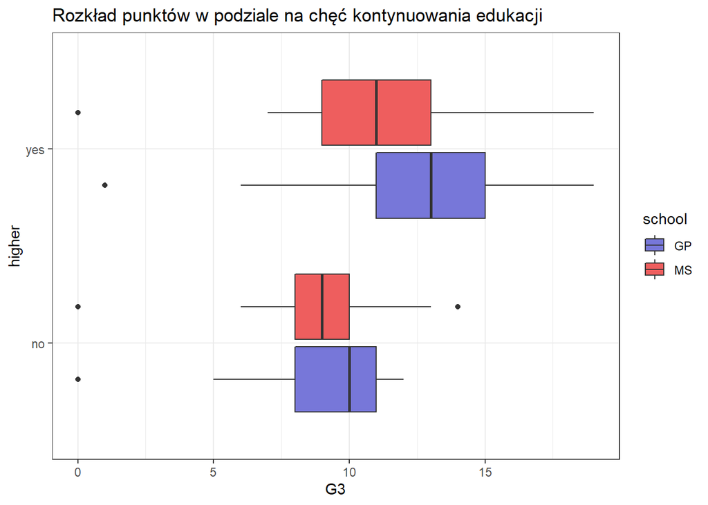

Zauważyć można, że mediana punktów uzyskiwanych przez uczniów, którzy zamierzają kontynuować edukację, jest wyższa dla obu szkół.

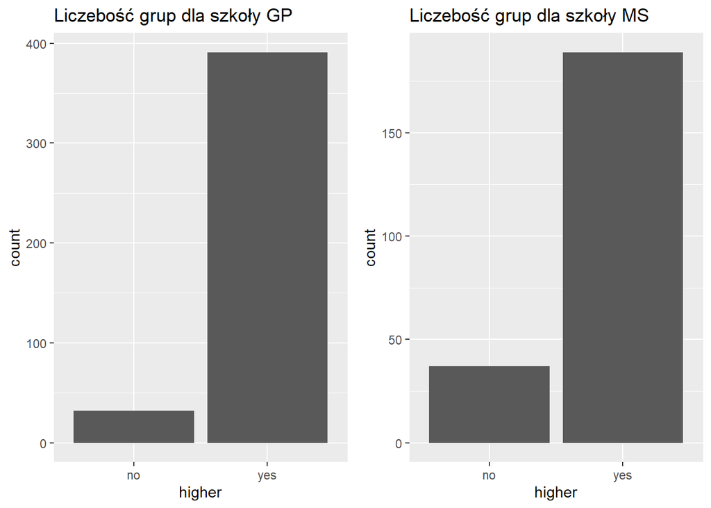

W obu szkołach uczniowie w dużej mierze chcą kontynuować swoją edukację.

$H_0$: Niezależność uczęszczania na zajęcia pozalekcyjne oraz liczby uzyskanych punktów końcowych.

$H_1$: Brak niezależności uczęszczania na zajęcia pozalekcyjne oraz liczby uzyskanych punktów końcowych.

```
##
##  Pearson's Chi-squared test
##
## data:  tab
## X-squared = 21.63, df = 16, p-value = 0.1556
```

Nie ma podstaw do odrzucenia hipotezy o niezależności cech.

$H_0$: Niezależność uczęszczania na dodatkowo płatne zajęcia z języka portugalskiego oraz liczby uzyskanych punktów końcowych.

$H_1$: Brak niezależności uczęszczania na dodatkowo płatne zajęcia z języka portugalskiego oraz liczby uzyskanych punktów końcowych.

```
##
##  Pearson's Chi-squared test
##
## data:  tab
## X-squared = 14.099, df = 16, p-value = 0.5913
```

Nie ma podstaw do odrzucenia $H_0$ o niezależności cech.

$H_0$: Niezależność otrzymywania rodzinnego wsparcia edukacyjnego oraz liczby uzyskanych punktów końcowych.

$H_0$: Brak niezależności otrzymywania rodzinnego wsparcia edukacyjnego oraz liczby uzyskanych punktów końcowych.

```
##
##  Pearson's Chi-squared test
##
## data:  tab
## X-squared = 19.48, df = 16, p-value = 0.2446
```

Nie ma podstaw do odrzucenia hipotezy zerowej. Zatem cechy są niezależne.

$H_0$: Niezależność ilość niezdanych klas przez ucznia oraz uliczby zyskanych punktów końcowych.

$H_1$: Brak niezależności ilość niezdanych klas przez ucznia oraz liczby uzyskanych punktów końcowych.

Badamy normalność:

```
##
##  Shapiro-Wilk normality test
##
## data:  dane$failures
## W = 0.42355, p-value < 2.2e-16
```

```
##
##  Asymptotic one-sample Kolmogorov-Smirnov test
##
## data:  dane$failures
## D = 0.49172, p-value < 2.2e-16
## alternative hypothesis: two-sided
```

Odrzucamy hipotezę o normalności. Stosujemy test Wilcox’ona.

```
##
##  Wilcoxon signed rank test with continuity correction
##
## data:  dane$failures
## V = 210925, p-value < 2.2e-16
## alternative hypothesis: true location is not equal to 0
```

Odrzucamy hipotezę o tym, że cechy mają takie same rozkłady. Zatem występuje brak zależności między cechami.

##### Podsumowanie

Na ilość punktów końcowych mają wpływ zmienne:

- `adress` - miejsce zamieszkania ucznia (możliwe wyższe ilości punktów dla uczniów mieszkających w mieście)
- `Medu` - poziom edukacji matki ucznia (mediana punktów wzrasta wraz z wyższym wykształceniem)
- `Fedu` - poziom edukacji ojca ucznia (mediana punktów wzrasta wraz z wyższym wykształceniem)
- `studytime` - czas spędzany na nauce (wraz ze wzrostem czasu poświęcanego na naukę w ciągu tygodnia, wyższa jest mediana punktów)
- `higher` - chęć kontynuowania edukacji (grupa uczniów, którzy zamierzają kontynuować edukację, wyróżnia się wyższą medianą punktów)
- `freetime` - ilość czasu wolnego po szkole (wyższa mediana punktów dla uczniów mających mniej czasu wolnego)
- `goout` - częstotliwość spotykania się ze znajomymi (wyższa mediana punktów dla uczniów rzadziej spotykających się ze znajomymi)
- `Dalc` - ilość spożywanego alkoholu w dni robocze (wyższa mediana punktów dla uczniów, w których domach spożywa się mniej alkolohu w dni robocze)
- `Walc` - ilość spożywanego alkoholu w weekendy (im mniejsza, tym mediana punktów wyższa)

## Niezależność cech

Zostały również przeprowadzone testy badające niezależność wybranyuch cech między sobą.

$H_0$: Niezależność wieku ucznia od ilości czasu spędzanego przez niego na nauce.

$H_1$: Brak niezależności wieku oraz ilości czasu spędzanego na nauce.

```
##
##  Pearson's Chi-squared test
##
## data:  tab
## X-squared = 18.958, df = 21, p-value = 0.5878
```

Nie ma podstaw do odrzucenia hipotezy zerowej. Zatem nie ma zależności między wiekiem ucznia, a czasem, jaki poświęca on na naukę.

$H_0$: Niezależność dostępu do internetu oraz ilości czasu spędzanego na nauce.

$H_1$: Brak niezależności dostępu do internetu od ilości czasu spędzanego na nauce.

```
##
##  Pearson's Chi-squared test
##
## data:  tab
## X-squared = 1.5851, df = 3, p-value = 0.6628
```

Nie ma podstaw do odrzucenia hipotezy zerowej. Zatem nie ma zależności między dostępem uczniów do internetu, a ilością czasu spędzanego przez nich na naukę.

$H_0$: Niezależność bycia przez ucznia w związku od ilości czasu spędzanego przez niego na nauce.

$H_1$: Brak niezależności między byciem przez ucznia w związku, a ilością czasu spędzanego na nauce.

```
##
##  Pearson's Chi-squared test
##
## data:  tab
## X-squared = 8.7279, df = 3, p-value = 0.03314
```

Odrzucamy $H_0$ na korzyść $H_1$. Zatem nie ma niezależności między badanymi cechami.

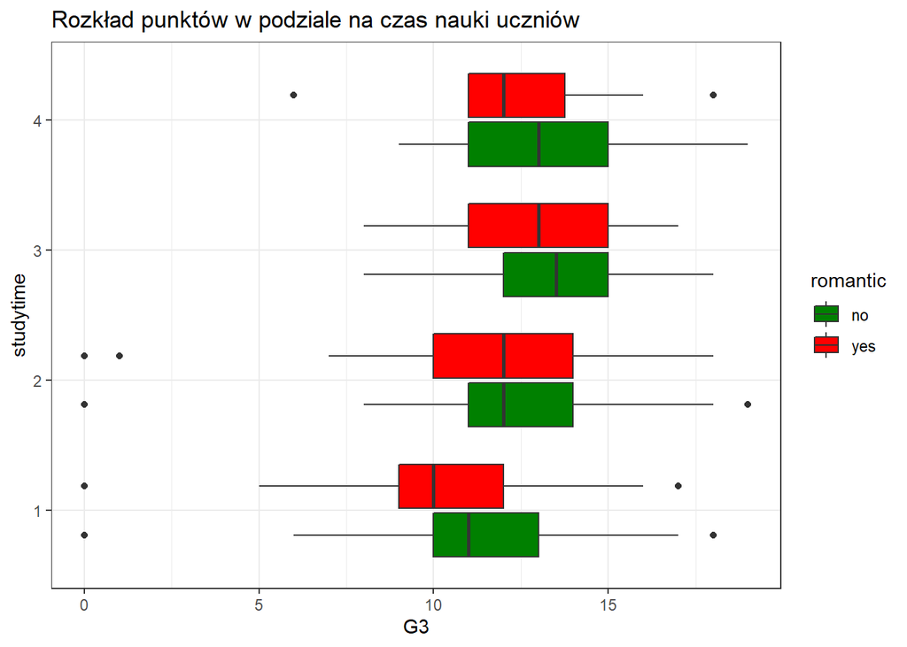

Zauważyć można, że zarówno uczniowie będący w związku, jak i w nim nie będący, im więcej czasu poświęcają nauce, tym zakres uzyskiwanych punktów obejmuje wyższe wartości i ich mediana jest nieco wyższa. Jednak uczniowie nie będący w związku mają wyższe zakresy punktów końcowych oraz ich mediany.

$H_0$: Niezależność ilości czasu spędzonego na spotykaniu się ze znajomymi od ilości czasu spędzanego na nauce.

$H_1$: Brak niezależności ilości czasu spędzonego na spotykaniu się ze znajomymi oraz ilości czasu spędzanego na nauce.

```
##
##  Pearson's Chi-squared test
##
## data:  tab
## X-squared = 30.564, df = 12, p-value = 0.002295
```

Odrzucamy hipotezę zerową na korzyść alternatywnej. Istnieje zatem zależność między ilością czasu spędzonego na spotykaniu się ze znajomymi, a ilością czasu spędzanego na nauce.

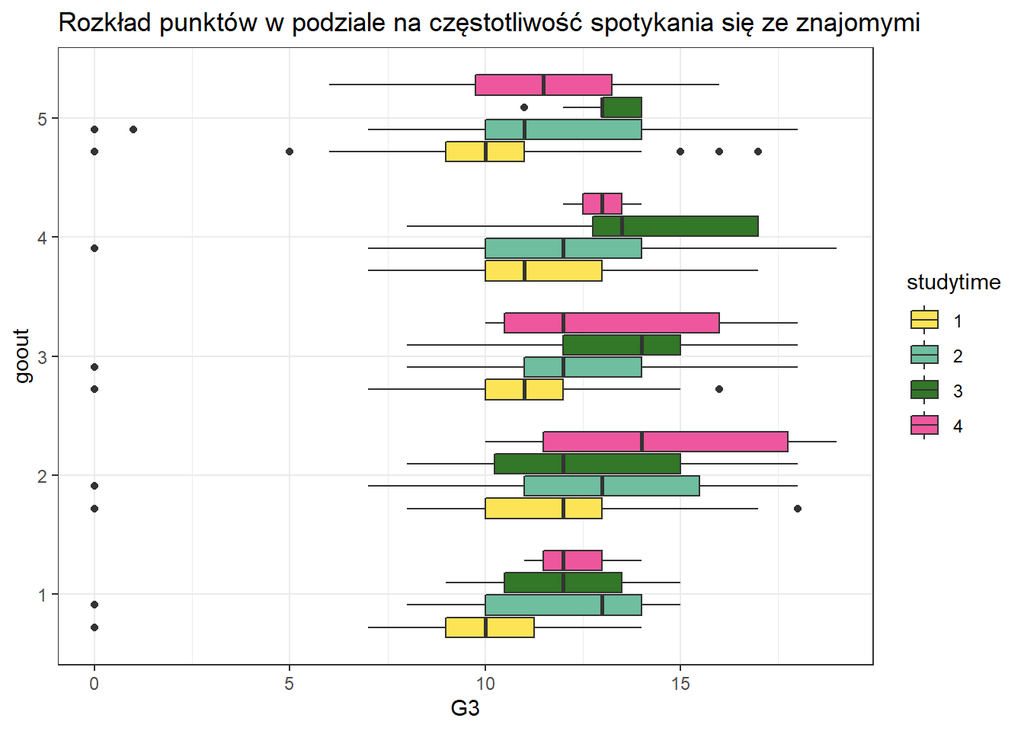

Uczniowie, którzy poświęcają czas na naukę na poziomie “3” (dużo) oraz ci, którzy ze znajomymi spotykają się na poziomie “3” oraz “4” (średnio oraz dużo), mają wyższe mediany ocen.

$H_0$: Niezależność bycia przez ucznia w związku od ilości czasu spędzonego na spotkaniach ze znajomymi.

$H_1$: Brak niezależności między byciem przez ucznia w związku, a ilości czasu spędzanego na spotkaniach ze znajomymi.

```
##
##  Pearson's Chi-squared test
##
## data:  tab
## X-squared = 3.3423, df = 4, p-value = 0.5023
```

Nie ma podstaw do odrzucenia $H_0$. Zatem ilość czasu, jaki uczeń poświęca na spotkania ze znajomymi, nie zależy od bycia przez niego w związku.

$H_0$: Niezależność chęci kontynuowania edukacji oraz ilości czasu spędzanego na nauce.

$H_1$: Brak niezależności między chęcią kontynuowania edukacji oraz ilością czasu spędzanego na nauce.

```
##
##  Pearson's Chi-squared test
##
## data:  tab
## X-squared = 34.3, df = 3, p-value = 1.712e-07
```

Odrzucamy hipotezę zerową na korzyść alternatywnej. Zatem mamy brak niezależności badanych cech.

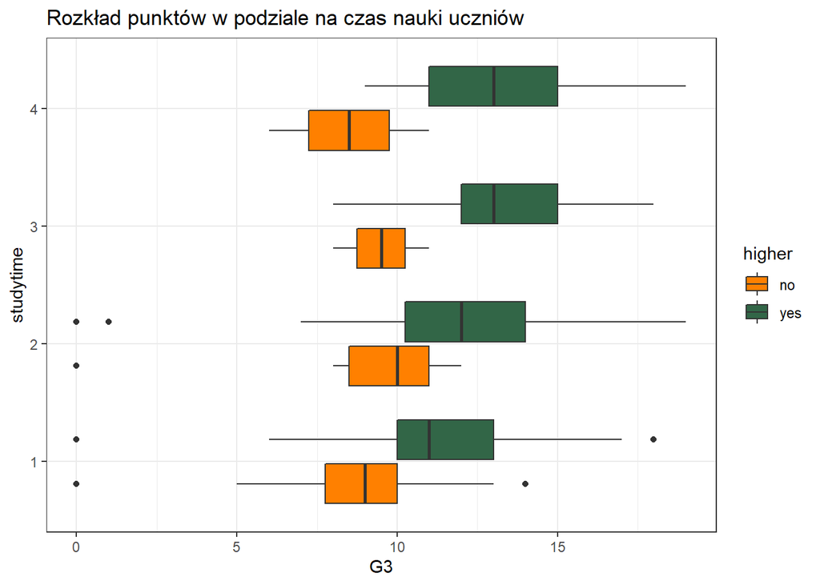

Uczniowie, którzy uczą się dużo więcej, a nie chcą kontynuować edukacji, mają niższe punkty od uczniów, którzy edukację chcą kontynuować.

$H_0$: Niezależność wieku oraz chęci kontynuowania edukacji.

$H_1$: Brak niezależności wieku uczniów oraz chęci kontynuowania przez nich edukacji.

```
##
##  Pearson's Chi-squared test
##
## data:  tab
## X-squared = 58.102, df = 7, p-value = 3.607e-10
```

Odrzucamy hipotezę zerową na korzyść alternatywnej.

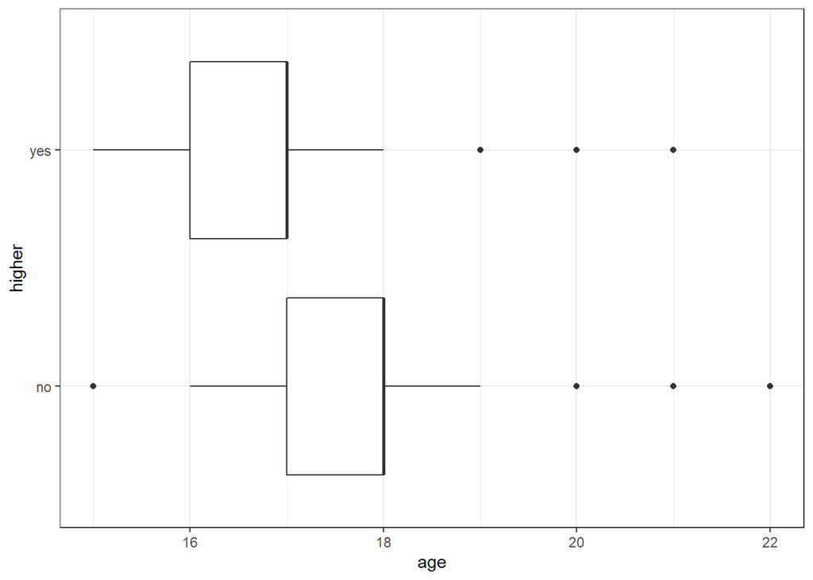

Uczniowie chcący kontynuować swoją edukację należą do grupy uczniów, ktorych obejmuje przedział wiekowy 15-18 lat. Nie chcący kontynuować edukacji są w grupie wiekowej 16-19 lat.

##### Podsumowanie

Na podstawie weryfikacji postawionych hipotez, istnieją zależności między:

- byciem przez ucznia w związku, a czasem poświęcanym na naukę
- ilością czasu spędzonego na spotykaniu się ze znajomymi, a ilością czasu spędzanego na nauce
- chęcią kontynuowania przez ucznia edukacji oraz ilością czasu spędzanego na nauce
- wiekiem ucznia oraz chęcią kontynuowania przez niego edukacji

## Testy nieparametryczne

Przeprowadzone zostaną testy nieparametryczne, aby zbadać czy poszczególne poziomy zmiennych kategorycznych, które, poprzez weryfikacje hipotez o ich wpływie na zmienną `G3`, mają wpływ na `G3`.

Są to zmienne: `adress`, `Medu`, `Fedu`, `studytime`, `higher`, `freetime`, `goout`, `Dalc` oraz `Walc`.

$H_0$: Zmienna `adress` oraz `G3` mają ten sam rozkład.

$H_1$: Zmienna `adress` oraz `G3` nie mają tego samego rozkładu.

```
##
##  Pearson's Chi-squared test
##
## data:  tab
## X-squared = 36.59, df = 16, p-value = 0.002394
```

Odrzucamy $H_0$ na korzyść $H_1$. Zatem miejsce zamieszkania ucznia poziomie “U” (w mieście) nie ma tgo samego rozkładu co `G3`.

```
##
##  Pearson's Chi-squared test
##
## data:  tab
## X-squared = 36.59, df = 16, p-value = 0.002394
```

Odrzucamy $H_0$ na korzyść $H_1$. Zatem miejsce zamieszkania ucznia poziomie “R” (na wsi) nie ma tgo samego rozkładu co `G3`.

$H_0$: Zmienna `Medu` oraz `G3` mają ten sam rozkład.

$H_1$: Zmienna `Medu` oraz `G3` nie mają tego samego rozkładu.

```
##
##  Pearson's Chi-squared test
##
## data:  tab
## X-squared = 8.2619, df = 16, p-value = 0.9407
```

Nie ma podstaw do odrzucenia $H_0$. Zatem poziom edukacji matki na poziomie 0 ma ten sam rozkład co `G3`.

```
##
##  Pearson's Chi-squared test
##
## data:  tab
## X-squared = 51.816, df = 16, p-value = 1.173e-05
```

Odrzucamy $H_0$ na korzysć $H_1$. Zatem poziom edukacji matki na poziomie 1 nie ma tego samego rozkładu co `G3`.

```
##
##  Pearson's Chi-squared test
##
## data:  tab
## X-squared = 18.845, df = 16, p-value = 0.2768
```

Nie ma podstaw do odrzucenia $H_0$. Zatem poziom edukacji matki na poziomie 2 ma ten sam rozkład co `G3`.

```
##
##  Pearson's Chi-squared test
##
## data:  tab
## X-squared = 19.819, df = 16, p-value = 0.2285
```

Nie ma podstaw do odrzucenia $H_0$. Zatem poziom edukacji matki na poziomie 3 ma ten sam rozkład co `G3`.

```
##
##  Pearson's Chi-squared test
##
## data:  tab
## X-squared = 53.74, df = 16, p-value = 5.717e-06
```

Odrzucamy $H_0$ na korzysć $H_1$. Zatem poziom edykacji matki na poziomie 4 nie ma tego samego rozkładu co `G3`.

$H_0$: Zmienna `Fedu` oraz `G3` mają ten sam rozkład.

$H_1$: Zmienna `Fedu` oraz `G3` nie mają tego samego rozkładu.

```
##
##  Pearson's Chi-squared test
##
## data:  tab
## X-squared = 9.0865, df = 16, p-value = 0.9098
```

Nie ma podstaw do odrzucenia $H_0$. Zatem poziom edukacji na poziomie 0 ma ten sam rozkład co `G3`.

```
##
##  Pearson's Chi-squared test
##
## data:  tab
## X-squared = 45.844, df = 16, p-value = 0.0001029
```

Odrzucamy $H_0$ na korzysć $H_1$. Zatem poziom edukacji ojca na poziomie 1 nie ma tego samego rozkładu co `G3`.

```
##
##  Pearson's Chi-squared test
##
## data:  tab
## X-squared = 16.309, df = 16, p-value = 0.4316
```

Nie ma podstaw do odrzucenia $H_0$. Zatem poziom edukacji ojca na poziomie 2 ma ten sam rozkład co `G3`.

```
##
##  Pearson's Chi-squared test
##
## data:  tab
## X-squared = 22.068, df = 16, p-value = 0.141
```

Nie ma podstaw do odrzucenia $H_0$. Zatem poziom edukacji ojca na poziomie 3 ma ten sam rozkład co `G3`.

```
##
##  Pearson's Chi-squared test
##
## data:  tab
## X-squared = 45.657, df = 16, p-value = 0.00011
```

Odrzucamy $H_0$ na korzysć $H_1$. Zatem poziom edukacji ojca na poziomie 4 nie ma tego samego rozkładu co `G3`.

$H_0$: Zmienna `studytime` oraz `G3` mają ten sam rozkład.

$H_1$: Zmienna `studytime` oraz `G3` nie mają tego samego rozkładu.

```
##
##  Pearson's Chi-squared test
##
## data:  tab
## X-squared = 50.993, df = 16, p-value = 1.591e-05
```

Odrzucamy hipotezę zerową na korzysć alternatywnej. Zatem tygodniowy czas spędzany na nauce na poziomie 1 nie ma tego samego rozkładu co `G3`.

```
##
##  Pearson's Chi-squared test
##
## data:  tab
## X-squared = 13.899, df = 16, p-value = 0.6063
```

Nie ma podstaw do odrzucenia $H_0$. Zatem tygodniowy czas spędzany na nauce na poziomie 2 ma ten sam rozkład co `G3`.

```
##
##  Pearson's Chi-squared test
##
## data:  tab
## X-squared = 31.904, df = 16, p-value = 0.01029
```

Odrzucamy hipotezę zerową na korzyść alternatywnej. Zatem tygodniowy czas spędzany na nauce na poziomie 3 nie ma tego samego rozkładu co `G3`.

```
##
##  Pearson's Chi-squared test
##
## data:  tab
## X-squared = 25.229, df = 16, p-value = 0.06588
```

Nie ma podstaw do odrzucenia $H_0$. Zatem tygodniowy czas spędzany na nauce na poziomie 4 ma ten sam rozkład co `G3`.

$H_0$: Zmienna `higher` oraz `G3` mają ten sam rozkład.

$H_1$: Zmienna `higher` oraz `G3` nie mają tego samego rozkładu.

```
##
##  Pearson's Chi-squared test
##
## data:  tab
## X-squared = 106.7, df = 16, p-value = 1.898e-15
```

Odrzucamy $H_0$ na korzyść $H_1$. Zatem chęć kontynuowania edukacji nie ma tego samego rozkładu co `G3`.

```
##
##  Pearson's Chi-squared test
##
## data:  tab
## X-squared = 106.7, df = 16, p-value = 1.898e-15
```

Odrzucamy $H_0$ na korzyść $H_1$. Zatem brak chęci kontynuowania edukacji nie ma tego samego rozkładu co `G3`.

$H_0$: Zmienna `freetime` oraz `G3` mają ten sam rozkład.

$H_1$: Zmienna `freetime` oraz `G3` nie mają tego samego rozkładu.

```
##
##  Pearson's Chi-squared test
##
## data:  tab
## X-squared = 23.231, df = 16, p-value = 0.1077
```

Nie ma podstaw do odrzucenia $H_0$. Ilość czasu wolnego na poziomie 1 oraz `G3` mają ten sam rozkład.

```
##
##  Pearson's Chi-squared test
##
## data:  tab
## X-squared = 24.87, df = 16, p-value = 0.07216
```

Nie ma podstaw do odrzucenia $H_0$. Ilość czasu wolnego na poziomie 2 oraz `G3` mają ten sam rozkład.

```
##
##  Pearson's Chi-squared test
##
## data:  tab
## X-squared = 13.577, df = 16, p-value = 0.6302
```

Nie ma podstaw do odrzucenia $H_0$. Ilość czasu wolnego na poziomie 3 oraz `G3` mają ten sam rozkład.

```
##
##  Pearson's Chi-squared test
##
## data:  tab
## X-squared = 15.799, df = 16, p-value = 0.4671
```

Nie ma podstaw do odrzucenia $H_0$. Ilość czasu wolnego na poziomie 4 oraz `G3` mają ten sam rozkład.

```
##
##  Pearson's Chi-squared test
##
## data:  tab
## X-squared = 26.752, df = 16, p-value = 0.04432
```

Odrzucamy $H_0$ na korzyść $H_1$. Ilość czasu wolnego na poziomie 5 oraz `G3` nie mają tego samego rozkładu.

$H_0$: Zmienna `goout` oraz `G3` mają ten sam rozkład.

$H_1$: Zmienna `goout` oraz `G3` nie mają tego samego rozkładu.

```
##
##  Pearson's Chi-squared test
##
## data:  tab
## X-squared = 31.954, df = 16, p-value = 0.01014
```

Odrzucamy $H_0$ na korzyść $H_1$. Spotykanie się ze znajomymi na poziomie 1 oraz `G3` nie mają tego samego rozkładu.

```
##
##  Pearson's Chi-squared test
##
## data:  tab
## X-squared = 23.708, df = 16, p-value = 0.09607
```

Nie ma podstaw do odrzucenia $H_0$. Spotykanie się ze znajomymi na poziomie 2 oraz `G3` mają ten sam rozkład.

```
##
##  Pearson's Chi-squared test
##
## data:  tab
## X-squared = 15.147, df = 16, p-value = 0.5139
```

Nie ma podstaw do odrzucenia $H_0$. Spotykanie się ze znajomymi na poziomie 3 oraz `G3` mają ten sam rozkład.

```
##
##  Pearson's Chi-squared test
##
## data:  tab
## X-squared = 13.719, df = 16, p-value = 0.6197
```

Nie ma podstaw do odrzucenia $H_0$. Spotykanie się ze znajomymi na poziomie 4 oraz `G3` mają ten sam rozkład.

```
##
##  Pearson's Chi-squared test
##
## data:  tab
## X-squared = 43.486, df = 16, p-value = 0.000236
```

Odrzucamy $H_0$ na korzyść $H_1$. Spotykanie się ze znajomymi na poziomie 5 oraz `G3` nie mają tego samego rozkładu.

$H_0$: Zmienna `Dalc` oraz `G3` mają ten sam rozkład.

$H_1$: Zmienna `Dalc` oraz `G3` nie mają tego samego rozkładu.

```
##
##  Pearson's Chi-squared test
##
## data:  tab
## X-squared = 41.524, df = 16, p-value = 0.0004645
```

Odrzucamy $H_0$ na korzyść $H_1$. Picie alkoholu w dni robocze na poziomie 1 oraz `G3` nie mają tego samego rozkładu.

```
##
##  Pearson's Chi-squared test
##
## data:  tab
## X-squared = 11.998, df = 16, p-value = 0.7441
```

Nie ma podstaw do odrzucenia $H_0$. Picie alkoholu w dni robocze na poziomie 2 oraz `G3` mają ten sam rozkład.

```
##
##  Pearson's Chi-squared test
##
## data:  tab
## X-squared = 22.696, df = 16, p-value = 0.1221
```

Nie ma podstaw do odrzucenia $H_0$. Picie alkoholu w dni robocze na poziomie 3 oraz `G3` mają ten sam rozkład.

```
##
##  Pearson's Chi-squared test
##
## data:  tab
## X-squared = 64.084, df = 16, p-value = 1.058e-07
```

Odrzucamy $H_0$ na korzyść $H_1$. Picie alkoholu w dni robocze na poziomie 4 oraz `G3` nie mają tego samego rozkładu.

```
##
##  Pearson's Chi-squared test
##
## data:  tab
## X-squared = 60.537, df = 16, p-value = 4.248e-07
```

Odrzucamy $H_0$ na korzyść $H_1$. Picie alkoholu w dni robocze na poziomie 5 oraz `G3` nie mają tego samego rozkładu.

$H_0$: Zmienna `Walc` oraz `G3` mają ten sam rozkład.

$H_1$: Zmienna `Walc` oraz `G3` nie mają tego samego rozkładu.

```
##
##  Pearson's Chi-squared test
##
## data:  tab
## X-squared = 13.948, df = 16, p-value = 0.6026
```

Nie ma podstaw do odrzucenia $H_0$. Picie alkoholu w weekendy na poziomie 1 oraz `G3` mają ten sam rozkład.

```
##
##  Pearson's Chi-squared test
##
## data:  tab
## X-squared = 10.682, df = 16, p-value = 0.8287
```

Nie ma podstaw do odrzucenia $H_0$. Picie alkoholu w weekendy na poziomie 2 oraz `G3` mają ten sam rozkład.

```
##
##  Pearson's Chi-squared test
##
## data:  tab
## X-squared = 21.903, df = 16, p-value = 0.1463
```

Nie ma podstaw do odrzucenia $H_0$. Picie alkoholu w weekendy na poziomie 3 oraz `G3` mają ten sam rozkład.

```
##
##  Pearson's Chi-squared test
##
## data:  tab
## X-squared = 34.382, df = 16, p-value = 0.004824
```

Odrzucamy $H_0$ na korzyść $H_1$. Picie alkoholu w weekendy na poziomie 4 oraz `G3` nie mają tego samego rozkładu.

```
##
##  Pearson's Chi-squared test
##
## data:  tab
## X-squared = 40.596, df = 16, p-value = 0.0006368
```

Odrzucamy $H_0$ na korzyść $H_1$. Picie alkoholu w weekendy na poziomie 5 oraz `G3` nie mają tego samego rozkładu.

##### Podsumowanie

Następujące kategorie badanych zmiennych mają wpływ na ilość punktów końcowych uczniów (`G3`):

- `adress`: brak
- `Medu`: 0 - brak edukacji matki, 2 - poziom edukacji matki na poziomie ukończenia 5-9. klasy, 3 - wykształcenie średnie matki
- `Fedu`: 0 - brak edukacji ojca, 2 - poziom edukacji ojca na poziomie ukończenia 5-9. klasy, 3 - wykształcenie średnie ojca
- `studytime`: 2 - tygodniowy czas nauki od 2 do 5 godzin, 4 - tygodniowy czas nauki od 5 do 10 godzin
- `higher`: brak
- `freetime`: 1 - bardzo mało czasu wolnego, 2 - mało czasu wolnego, 3 - średnia ilość czasu wolnego, 4 - duża ilość czasu wolnego
- `goout`: 2 - mało okazji do spotykania się ze znajomymi, 3 - średnia ilość takich okazji, 4 - duża ilość
- `Dalc`: 2 - mała ilość alkoholu spożywana w dni robocze, 3 - średnia ilość alkoholu spożywana w dni robocze
- `Walc`: 1 - bardzo mała ilość alkoholu spożywana w weekendy, 2 - mała ilość spożywanego alkoholu w weekendy, 3 - średnia ilość spożywania alkoholu w weekendy

## Analiza wariancji (ANOVA)

Analiza wariancji to metoda służąca do porównania wartości oczekiwanych kilku populacji normalnych.

Będziemy badać zmienne: `adress`, `Medu`, `Fedu`, `studytime`, `higher`, `freetime`, `goout`, `Dalc` oraz `Walc`, ponieważ te okazały się wpływać na badaną cechę (`G3`).

Założenia ANOVA:

- badamy k populacji (grup) charakteryzowanych przez zmienną $X$. Zmienne $X_1$,$X_2$,$…$,$X_k$ przypisane grupom $1,2,…,k$ są niezależne i mają rozkłady normalne
- wszystkie populacje (grupy) mają jednakowe wariancje
- Będziemy badać zmienną `G3` w podziale ze względu na `adress` (miejsce zamieszkania ucznia o możliwych dwóch poziomach).

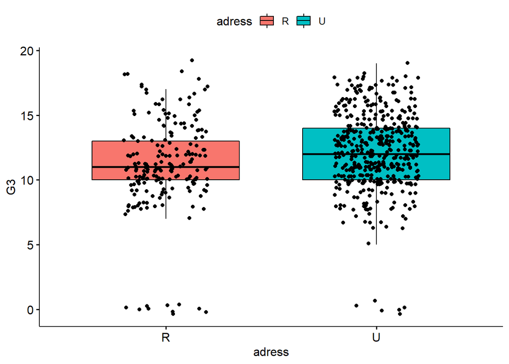

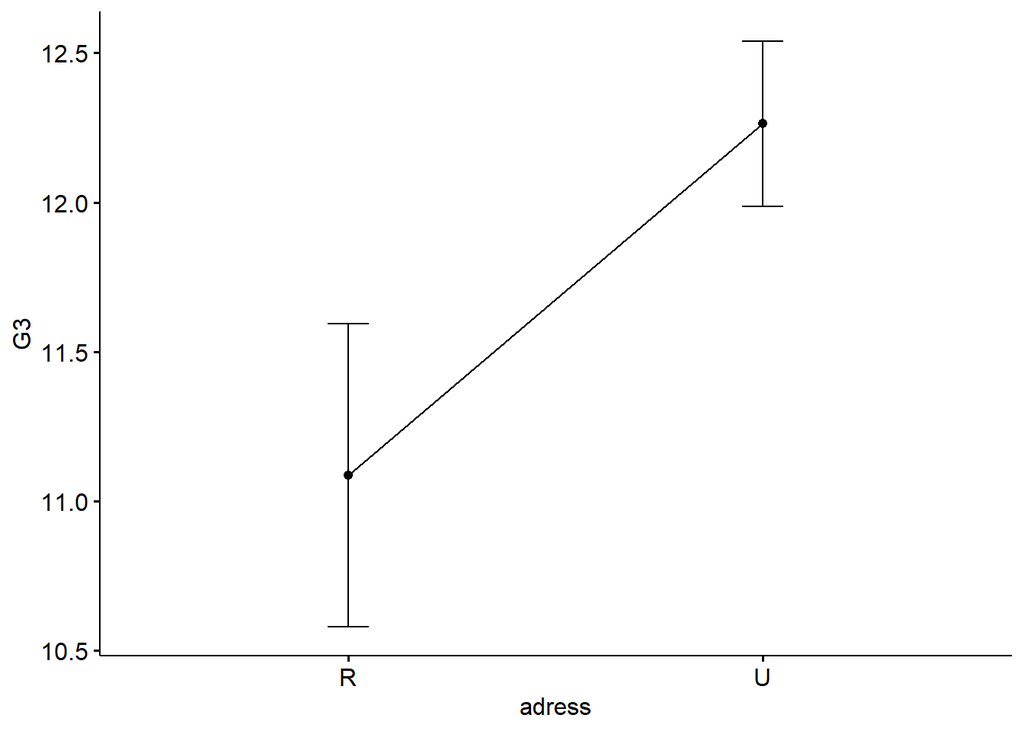

Dostrzec można zauważalną różnicę w średnich w grupach.

Sprawdzamy założenia.

```
##   adress   n
## 1      R 197
## 2      U 452
```

Grupy są liczne. Mozemy przejść do badania normalności.

$H_0$: Rozkład cechy jest rozkładem normalnym.

$H_1$: Rozkład cechy nie jest rozkładem normalnym.

| adress | variable | statistic | p |
| --- | --- | --- | --- |
| R | G3 | 0.8890301 | 0 |
| U | G3 | 0.9487893 | 0 |

Sprawdzamy równość wariancji.

$H_0$: Wariancje w grupach są równe.

$H_1$: Wariancje w grupach nie są równe.

```
## Levene's Test for Homogeneity of Variance (center = median)
##        Df F value Pr(>F)
## group   1   0.724 0.3952
##       647
```

Nie ma podstaw do odrzucenia $H_0$ o równości wariancji w grupach.

Przechodzimy zatem do budowy modelu:

```
##              Df Sum Sq Mean Sq F value   Pr(>F)
## adress        1    190  190.06   18.71 1.76e-05 ***
## Residuals   647   6573   10.16
## ---
## Signif. codes:  0 '***' 0.001 '**' 0.01 '*' 0.05 '.' 0.1 ' ' 1
```

Na poziomie istotności 0,05 odrzucamy hipotezę o tym, że średnie w każdej z grup są sobie równe, na korzyść hipotezy alternatywnej, że istnieje conajmniej jedna średnia grupowa istotnie różniąca się od pozostałych. Sprawdzimy to testem post-hoc LSD Fishera.

```
##
## Study: mod_adress ~ "adress"
##
## LSD t Test for G3
## P value adjustment method: bonferroni
##
## Mean Square Error:  10.15951
##
## adress,  means and individual ( 95 %) CI
##
##         G3      std   r      LCL      UCL Min Max
## R 11.08629 3.605221 197 10.64037 11.53222   0  19
## U 12.26327 2.987658 452 11.96888 12.55767   0  19
##
## Alpha: 0.05 ; DF Error: 647
## Critical Value of t: 1.963637
##
## Groups according to probability of means differences and alpha level( 0.05 )
##
## Treatments with the same letter are not significantly different.
##
##         G3 groups
## U 12.26327      a
## R 11.08629      b
```

Test potwierdza wysunięte wcześniej przypuszczenia, że średnie w badanych grupach znacznie się różnią.

- Będziemy badać zmienną `G3` w podziale ze względu na `Medu` (poziom edukacji matki o możliwych pięciu poziomach).

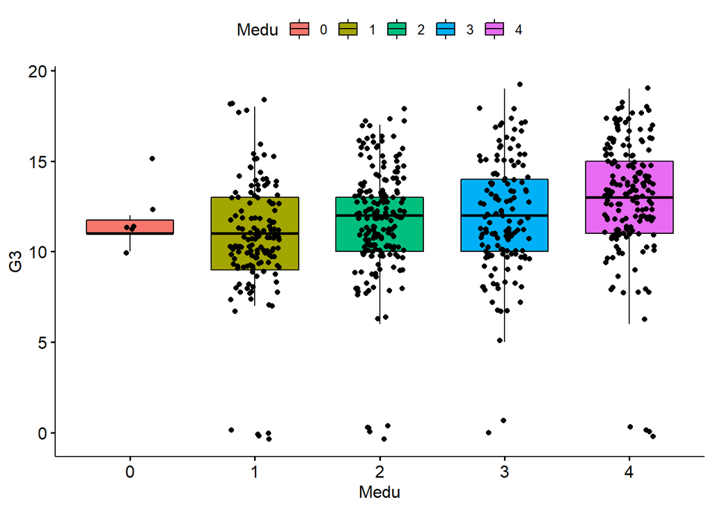

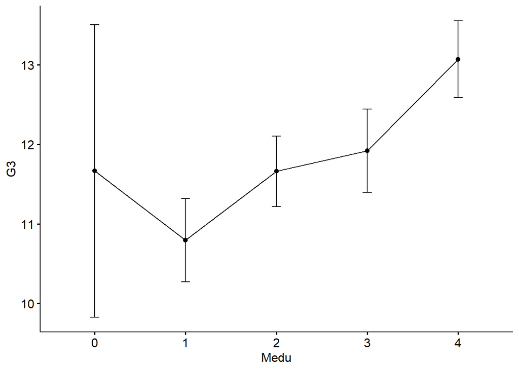

Z obu wykresów widać, że mediana oraz średnia punktów dla poziomu edukacji matki równym 4 jest lepsza niż dla pozostałych poziomów.

Sprawdzamy założenia.

```
##   Medu   n
## 1    0   6
## 2    1 143
## 3    2 186
## 4    3 139
## 5    4 175
```

Grupy, poza grupą “0”, są liczne. W przypadku małych prób, które nie spełniają założenia o normalności, należy zwrócić szczególną uwagę na kurtozę rozkładu; kurtoza w przypadku gdy jest większa od 0, powoduje zaniżenie wartości F.

Poniżej przedstawione mamy wskaźniki kurtozy dla poszczególnych poziomów zmiennej `Medu`. Jak widzimy, dla poziomu 0, jest ona znacznie większa od 0, co może mieć wpływ na wartość statystyki F.

```
## [1] 103.9846
```

```
## [1] -0.1710137
```

```
## [1] -1.108314
```

```
## [1] -0.04953628
```

```
## [1] -0.9200726
```

$H_0$: Rozkład cechy jest rozkładem normalnym.

$H_1$: Rozkład cechy nie jest rozkładem normalnym.

| Medu | variable | statistic | p |
| --- | --- | --- | --- |
| 0 | G3 | 0.7968913 | 0.0550982 |
| 1 | G3 | 0.8942401 | 0.0000000 |
| 2 | G3 | 0.8963792 | 0.0000000 |
| 3 | G3 | 0.9620790 | 0.0006759 |
| 4 | G3 | 0.8928179 | 0.0000000 |

Z testu Shapiro-Wilka wnioskujemy, że dla poziomu 0 nie ma podstaw do odrzucenia hipotezy o normalności. Dla pozostałych poziomów odrzucamy.

Przedstawiony poniżej wykres normalności Q-Q skłania do wyciągnięcia wniosku o braku normalności rozkładu badanej cechy.

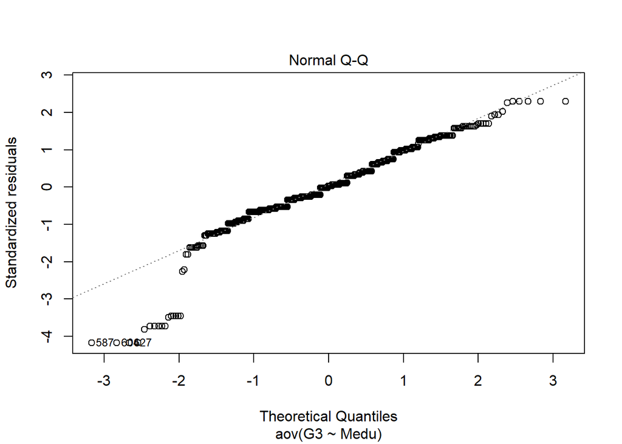

Sprawdzamy równość wariancji.

$H_0$: Wariancje w grupach są równe.

$H_1$: Wariancje w grupach nie są równe.

```
## Levene's Test for Homogeneity of Variance (center = median)
##        Df F value Pr(>F)
## group   4  0.8464 0.4961
##       644
```

Nie ma podstaw do odrzucenia hipotezy o równości wariancji.

Mimo, że test Shapiro-Wilka odrzucił hipotezę o normalności reszt dla większości poziomów badanej zmiennej, to test F jest odporny na brak normalności efektu losowego. Szczególnie małe znaczenie ma to założenie w przypadku dużych liczebności w podgrupach. Tutaj grupy są liczne, zatem mimo to przeprowadzimy analizę wariancji.

Przechodzimy zatem do budowy modelu:

```
##              Df Sum Sq Mean Sq F value   Pr(>F)
## Medu          4    424  105.96   10.76 1.89e-08 ***
## Residuals   644   6339    9.84
## ---
## Signif. codes:  0 '***' 0.001 '**' 0.01 '*' 0.05 '.' 0.1 ' ' 1
```

Na poziomie istotności 0,05 odrzucamy hipotezę, że wszystkie średnie są równe ($H_0$: $\mu_1=\mu_2=\mu_3=\mu_4=\mu_5$ przeciwko $H_1$: istnieją $i,j∈\{1,2,3,4,5\}$, że $\mu_i≠\mu_j$). Zatem co najmniej jedna średnia grupowa jest różna istotnie od pozostałych. W celu odkrycia struktury średnich przeprowadzimy porównania wielokrotne testami post-hoc.

```
##
## Study: mod_Medu ~ "Medu"
##
## LSD t Test for G3
## P value adjustment method: bonferroni
##
## Mean Square Error:  9.84382
##
## Medu,  means and individual ( 95 %) CI
##
##         G3      std   r       LCL      UCL Min Max
## 0 11.66667 1.751190   6  9.151474 14.18186  10  15
## 1 10.79720 3.163523 143 10.281999 11.31241   0  18
## 2 11.66129 3.061232 186 11.209548 12.11303   0  18
## 3 11.92086 3.123229 139 11.398299 12.44343   0  19
## 4 13.06857 3.236978 175 12.602848 13.53429   0  19
##
## Alpha: 0.05 ; DF Error: 644
## Critical Value of t: 2.816741
##
## Groups according to probability of means differences and alpha level( 0.05 )
##
## Treatments with the same letter are not significantly different.
##
##         G3 groups
## 4 13.06857      a
## 3 11.92086      b
## 0 11.66667     bc
## 2 11.66129     bc
## 1 10.79720      c
```

```
##
## Study: mod_Medu ~ "Medu"
##
## Scheffe Test for G3
##
## Mean Square Error  : 9.84382
##
## Medu,  means
##
##         G3      std   r Min Max
## 0 11.66667 1.751190   6  10  15
## 1 10.79720 3.163523 143   0  18
## 2 11.66129 3.061232 186   0  18
## 3 11.92086 3.123229 139   0  19
## 4 13.06857 3.236978 175   0  19
##
## Alpha: 0.05 ; DF Error: 644
## Critical Value of F: 2.385766
##
## Groups according to probability of means differences and alpha level( 0.05 )
##
## Means with the same letter are not significantly different.
##
##         G3 groups
## 4 13.06857      a
## 3 11.92086      b
## 0 11.66667      b
## 2 11.66129      b
## 1 10.79720      b
```

Widzimy, że średnia punktów uzyskiwanych przez uczniów o poziomie edukacji matki nr 4 - wykształcenie wyższe, różni się od pozostałych poziomów. Potwierdziło to zatem wcześniejsze przypuszczenia.

- Będziemy badać zmienną `G3` w podziale ze względu na `Fedu` (poziom edukacji ojca o możliwych pięciu poziomach).

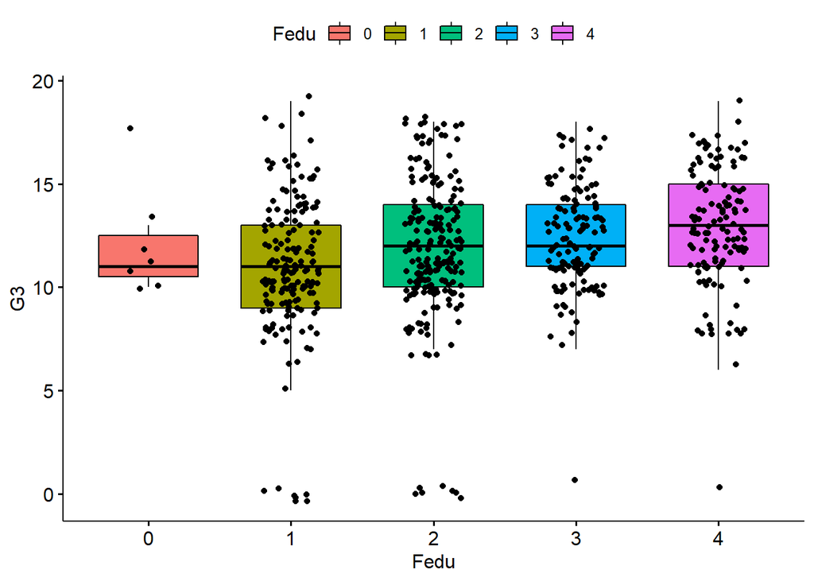

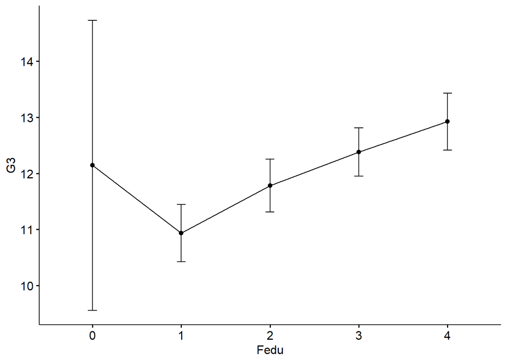

Zauważyć można wzrost mediany oraz średniej punktów uczniów, których ojcowie mają wyższy poziom edukacji.

Sprawdzamy założenia.

```
##   Fedu   n
## 1    0   7
## 2    1 174
## 3    2 209
## 4    3 131
## 5    4 128
```

Podobnie, jak w przypadku zmiennej `Medu`, grupy, poza “0” są liczne, jednak grupa “0” to jedynie 7 obserwacji. Obliczymy dla niej kurtozę.

[output not shown]

Kurtoza znacznie przewyższa wartość 0, co może mieć wpływ na wartość statystyki F. Dodatkowo, na poprzednim wykresie, można było zauważyć, że przedział ufności dla cechy `Fedu` dla poziomu 0, był bardzo duży i zawierał w sobie przedziały ufności wszystkich innych poziomów tej cechy.

$H_0$: Rozkład cechy jest rozkładem normalnym.

$H_1$: Rozkład cechy nie jest rozkładem normalnym.

| Fedu | variable | statistic | p |
| --- | --- | --- | --- |
| 0 | G3 | 0.7772924 | 0.0242478 |
| 1 | G3 | 0.9133405 | 0.0000000 |
| 2 | G3 | 0.9086740 | 0.0000000 |
| 3 | G3 | 0.9506248 | 0.0001188 |
| 4 | G3 | 0.9487948 | 0.0001044 |

Odrzucamy hipotezę o normalności dla wszystkich poziomów cechy.

Sprawdzamy równość wariancji.

$H_0$: Wariancje w grupach są równe.

$H_1$: Wariancje w grupach nie są równe.

```
## Levene's Test for Homogeneity of Variance (center = median)
##        Df F value Pr(>F)
## group   4  1.6449 0.1613
##       644
```

Nie ma podstaw do odrzucenia hipotezy o równości wariancji.

Założenie o normalności nie jest spełnione, a o równości wariancji tak. Jednak ze względu na to, że test F jest odporny na brak normalności efektu losowego, oraz na liczność poszczególnych poziomów badanej cechy, ANOVA zostanie przeprowadzona.

```
##              Df Sum Sq Mean Sq F value  Pr(>F)
## Fedu          4    329   82.16   8.223 1.8e-06 ***
## Residuals   644   6435    9.99
## ---
## Signif. codes:  0 '***' 0.001 '**' 0.01 '*' 0.05 '.' 0.1 ' ' 1
```

Na poziomie istotności 0,05 odrzucamy hipotezę, że wszystkie średnie są równe (hipoteza zerowa to $\mu_1=\mu_2=\mu_3=\mu_4=\mu_5$ przeciwko hipotezie alternatywnej, że istnieją $i,j∈\{1,2,3,4,5\}$, że $\mu_i≠\mu_j$). Zatem co najmniej jedna średnia grupowa jest różna istotnie od pozostałych. W celu odkrycia struktury średnich w badanych grupach przeprowadzimy porównania wielokrotne testami post-hoc.

```
##
## Study: mod_Fedu ~ "Fedu"
##
## LSD t Test for G3
## P value adjustment method: bonferroni
##
## Mean Square Error:  9.991627
##
## Fedu,  means and individual ( 95 %) CI
##
##         G3      std   r       LCL      UCL Min Max
## 0 12.14286 2.794553   7  9.796824 14.48889  10  18
## 1 10.93678 3.424077 174 10.466229 11.40733   0  19
## 2 11.78469 3.448321 209 11.355340 12.21404   0  18
## 3 12.38168 2.491394 131 11.839370 12.92399   1  18
## 4 12.92188 2.915096 128 12.373247 13.47050   0  19
##
## Alpha: 0.05 ; DF Error: 644
## Critical Value of t: 2.816741
##
## Groups according to probability of means differences and alpha level( 0.05 )
##
## Treatments with the same letter are not significantly different.
##
##         G3 groups
## 4 12.92188      a
## 3 12.38168     ab
## 0 12.14286    abc
## 2 11.78469     bc
## 1 10.93678      c
```

```
##
## Study: mod_Fedu ~ "Fedu"
##
## Scheffe Test for G3
##
## Mean Square Error  : 9.991627
##
## Fedu,  means
##
##         G3      std   r Min Max
## 0 12.14286 2.794553   7  10  18
## 1 10.93678 3.424077 174   0  19
## 2 11.78469 3.448321 209   0  18
## 3 12.38168 2.491394 131   1  18
## 4 12.92188 2.915096 128   0  19
##
## Alpha: 0.05 ; DF Error: 644
## Critical Value of F: 2.385766
##
## Groups according to probability of means differences and alpha level( 0.05 )
##
## Means with the same letter are not significantly different.
##
##         G3 groups
## 4 12.92188      a
## 3 12.38168     ab
## 0 12.14286    abc
## 2 11.78469     bc
## 1 10.93678      c
```

Jest różnica w średnich między grupą uczniów, których ojcowie mają poziom edukacji nr 1 oraz numery 3 i 4.

- Będziemy badać zmienną `G3` w podziale ze względu na `studytime` (tygodniowy czas nauki o możliwych czterech poziomach).

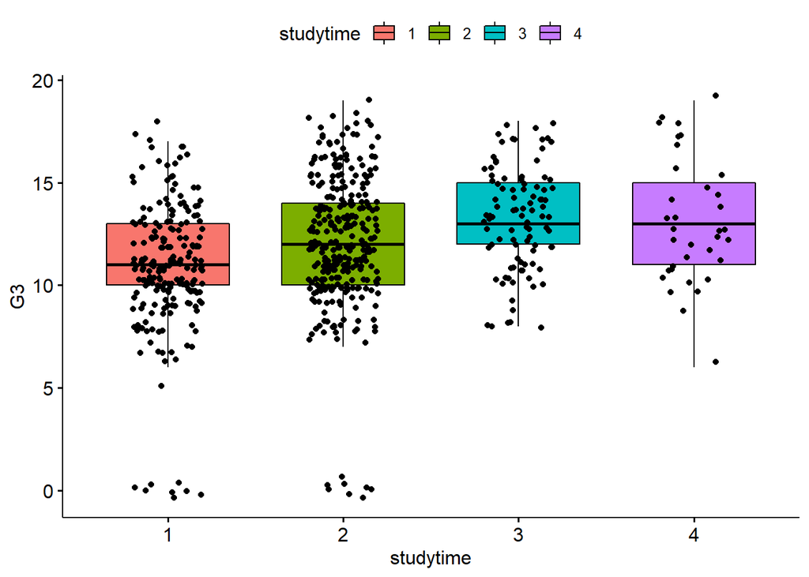

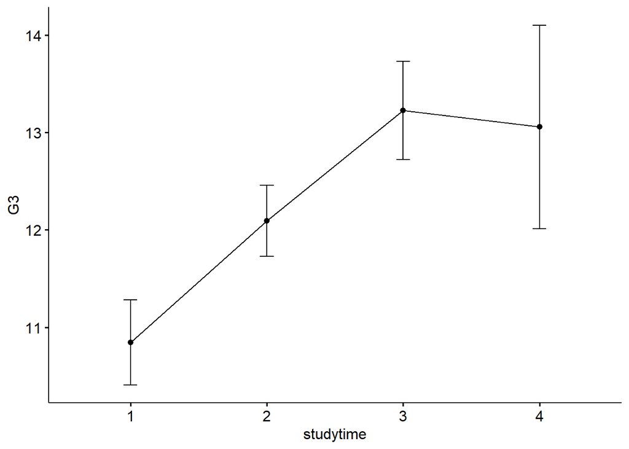

Widać wzrost mediany oraz średniej punktów dla uczniów poświęcających czas na naukę na poziomie 3 oraz 4. Przewidujemy istotną różnicę w średnich między poziomami 1 oraz 4.

Sprawdzamy założenia.

```
##   studytime   n
## 1         1 212
## 2         2 305
## 3         3  97
## 4         4  35
```

Grupy są liczne. Można zatem sprawdzić założenie o normalności.

$H_0$: Rozkład cechy jest rozkładem normalnym.

$H_1$: Rozkład cechy nie jest rozkładem normalnym.

| studytime | variable | statistic | p |
| --- | --- | --- | --- |
| 1 | G3 | 0.8979676 | 0.0000000 |
| 2 | G3 | 0.9170291 | 0.0000000 |
| 3 | G3 | 0.9698854 | 0.0249427 |
| 4 | G3 | 0.9554030 | 0.1659375 |

Jedynie `studytime` na poziomie 4 spełnia założenie o normalności.

Sprawdzamy równość wariancji.

$H_0$: Wariancje w grupach są równe.

$H_1$: Wariancje w grupach nie są równe.

```
## Levene's Test for Homogeneity of Variance (center = median)
##        Df F value Pr(>F)
## group   3  1.0263 0.3804
##       645
```

Nie ma podstaw do odrzucenia $H_0$. Zatem mamy równość wariancji w grupach.

Przeprawadzimy ANOVA mimo braku spełnienia założenia o normalności dla niektórych poziomów badanej cechy z powodów takich samych, jak to miało miejsce w analizie poprzednich zmiennych.

```
##              Df Sum Sq Mean Sq F value   Pr(>F)
## studytime     3    465  155.03   15.88 5.71e-10 ***
## Residuals   645   6298    9.76
## ---
## Signif. codes:  0 '***' 0.001 '**' 0.01 '*' 0.05 '.' 0.1 ' ' 1
```

Odrzucamy hipotezę, że wszystkie średnie są równe (hipoteza zerowa to $\mu_1=\mu_2=\mu_3=\mu_4$ przeciwko hipotezie alternatywnej, że istnieją $i,j∈\{1,2,3,4\}$, że $\mu_i≠\mu_j$).

Wniosek: Ilość czasu poświęcanego nauce powoduje istotne różnice w średniej punktów. Sprawdzimy struktury średnich testem post-hoc LSD Fishera.

```
##
## Study: mod_stud ~ "studytime"
##
## LSD t Test for G3
## P value adjustment method: bonferroni
##
## Mean Square Error:  9.764634
##
## studytime,  means and individual ( 95 %) CI
##
##         G3      std   r      LCL      UCL Min Max
## 1 10.84434 3.218624 212 10.42291 11.26577   0  18
## 2 12.09180 3.243125 305 11.74045 12.44315   0  19
## 3 13.22680 2.502104  97 12.60378 13.84983   8  18
## 4 13.05714 3.038410  35 12.01995 14.09433   6  19
##
## Alpha: 0.05 ; DF Error: 645
## Critical Value of t: 2.646421
##
## Groups according to probability of means differences and alpha level( 0.05 )
##
## Treatments with the same letter are not significantly different.
##
##         G3 groups
## 3 13.22680      a
## 4 13.05714     ab
## 2 12.09180      b
## 1 10.84434      c
```

Zauważyć można znaczącą różnicę między średnimi w grupie 1 oraz pozostałymi poziomami, co potwierdza wcześniejsze przypuszczenia.

- Będziemy badać zmienną `G3` w podziale ze względu na `higher` (chęć kontynuowania edukacji o możliwych dwóch poziomach).

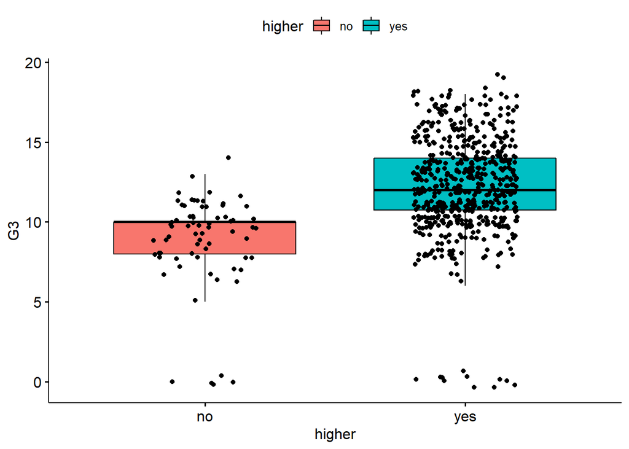

Na powyższym wykresie zauważyć można różnicę w medianach punktów uczniów na poszczególnych poziomach.

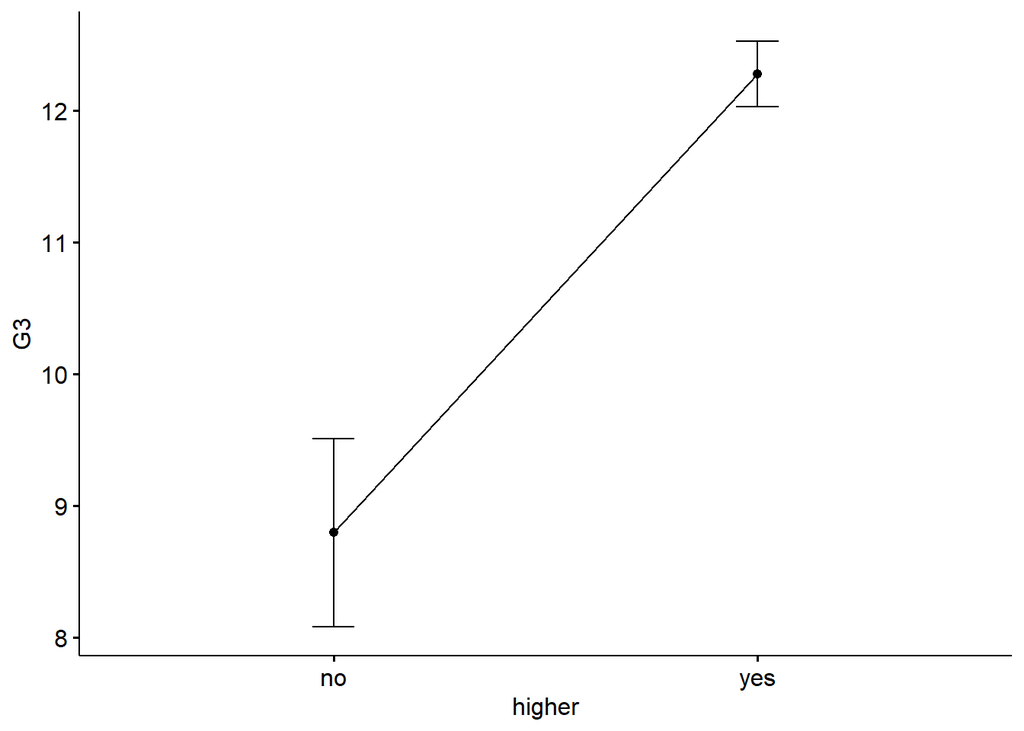

Na drugim wykresie widać znaczące różnice średnich w grupach. Uczniowie chcący kontynuować edukację są grupą mającą wyższą średnią punktów.

Sprawdzamy założenia.

```
##   higher   n
## 1     no  69
## 2    yes 580
```

Grupy są liczne. Można zatem sprawdzić założenie o normalności.

$H_0$: Rozkład cechy jest rozkładem normalnym.

$H_1$: Rozkład cechy nie jest rozkładem normalnym.

| higher | variable | statistic | p |
| --- | --- | --- | --- |
| no | G3 | 0.796863 | 0 |
| yes | G3 | 0.925798 | 0 |

Odrzucamy hipotezę o normalności dla obu poziomów.

Sprawdzamy równość wariancji.

$H_0$: Wariancje w grupach są równe.

$H_1$: Wariancje w grupach nie są równe.

```
## Levene's Test for Homogeneity of Variance (center = median)
##        Df F value Pr(>F)
## group   1  1.8676 0.1722
##       647
```

Nie ma podstaw do odrzucenia hipotezy o równości wariancji w grupach.

Mimo braku spełnienia założenia o normalności, decydujemy o przeprowadzeniu ANOVA ze względu na zauważalne duże różnice średnich w grupach na wykresie oraz ze względu na odporność testu F na brak normalności efektu losowego.

```
##              Df Sum Sq Mean Sq F value Pr(>F)
## higher        1    746   746.2   80.24 <2e-16 ***
## Residuals   647   6017     9.3
## ---
## Signif. codes:  0 '***' 0.001 '**' 0.01 '*' 0.05 '.' 0.1 ' ' 1
```

Odrzucamy hipotezę, że wszystkie średnie są równe ($H_0$: $\mu_1=\mu_2$ przy hipotezie alternatywnej, że istnieją $i,j∈\{1,2\}$, że $\mu_i≠\mu_j$).

Naszym wnioskiem jest, że chęć kontynuowania edukacji powoduje istotne różnice w średniej punktów. Sprawdźmy jak wyglądają różnice średnich w grupach testem poct-hoc LSD Fishera oraz testem Scheffe.

```
##
## Study: mod_higher ~ "higher"
##
## LSD t Test for G3
## P value adjustment method: bonferroni
##
## Mean Square Error:  9.299879
##
## higher,  means and individual ( 95 %) CI
##
##            G3      std   r       LCL       UCL Min Max
## no   8.797101 2.973311  69  8.076201  9.518002   0  14
## yes 12.275862 3.058402 580 12.027214 12.524511   0  19
##
## Alpha: 0.05 ; DF Error: 647
## Critical Value of t: 1.963637
##
## Groups according to probability of means differences and alpha level( 0.05 )
##
## Treatments with the same letter are not significantly different.
##
##            G3 groups
## yes 12.275862      a
## no   8.797101      b
```

```
##
## Study: mod_higher ~ "higher"
##
## Scheffe Test for G3
##
## Mean Square Error  : 9.299879
##
## higher,  means
##
##            G3      std   r Min Max
## no   8.797101 2.973311  69   0  14
## yes 12.275862 3.058402 580   0  19
##
## Alpha: 0.05 ; DF Error: 647
## Critical Value of F: 3.855871
##
## Groups according to probability of means differences and alpha level( 0.05 )
##
## Means with the same letter are not significantly different.
##
##            G3 groups
## yes 12.275862      a
## no   8.797101      b
```

Widzimy istotne różnice średnich uzyskiwanych punktów w grupach.

- Będziemy badać zmienną `G3` w podziale ze względu na `freetime` (ilość czasu wolnego o możliwych pięciu poziomach).

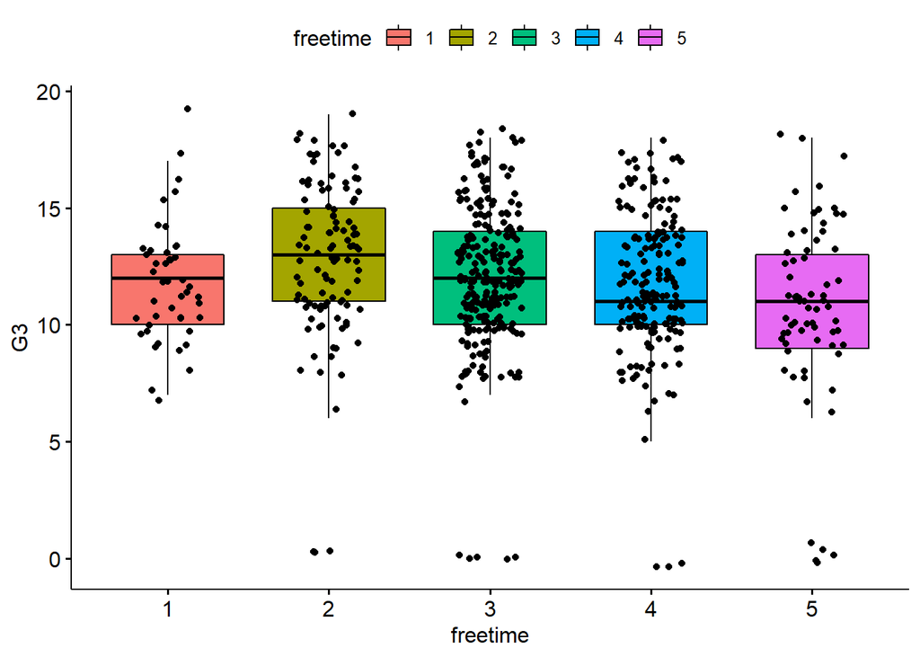

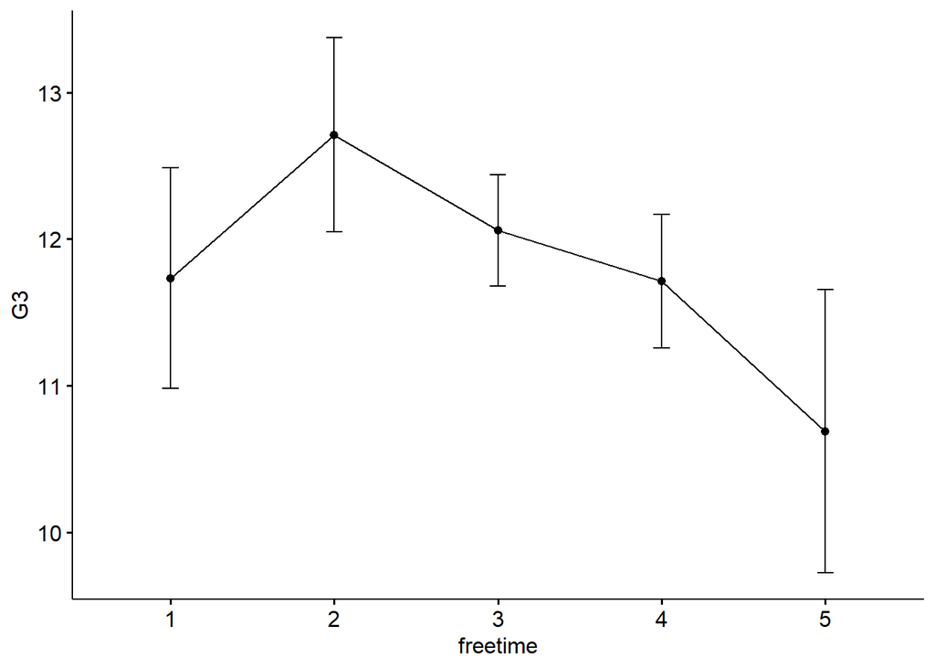

Dla uczniów mających więcej wolnego czasu, zauważyć można nieco niższą średnią punktów. Możliwa istotna różnica średnich między grupami “2” oraz “5”.

Sprawdzamy założenia.

```
##   freetime   n
## 1        1  45
## 2        2 107
## 3        3 251
## 4        4 178
## 5        5  68
```

Grupy są liczne. Można zatem sprawdzić założenie o normalności.

$H_0$: Rozkład cechy jest rozkładem normalnym.

$H_1$: Rozkład cechy nie jest rozkładem normalnym.

| freetime | variable | statistic | p |
| --- | --- | --- | --- |
| 1 | G3 | 0.9559799 | 0.0857736 |
| 2 | G3 | 0.9055045 | 0.0000013 |
| 3 | G3 | 0.9208325 | 0.0000000 |
| 4 | G3 | 0.9402716 | 0.0000009 |
| 5 | G3 | 0.9029092 | 0.0000640 |

Dla poziomu 1 nie ma podstaw do odrzucenia hipotezy o normalności. Dla pozostałych poziomów cechy `freetime` odrzucamy tę hipotezę.

Sprawdzamy równość wariancji.

$H_0$: Wariancje w grupach są równe.

$H_1$: Wariancje w grupach nie są równe.

```
## Levene's Test for Homogeneity of Variance (center = median)
##        Df F value Pr(>F)
## group   4  1.4311  0.222
##       644
```

Nie ma podstaw do odrzucenia hipotezy o równości wariancji w grupach.

Przeprowadzimy analizę wariancji mimo braku spełnienia założenia o normalności.

```
##              Df Sum Sq Mean Sq F value  Pr(>F)
## freetime      4    183   45.86   4.489 0.00139 **
## Residuals   644   6580   10.22
## ---
## Signif. codes:  0 '***' 0.001 '**' 0.01 '*' 0.05 '.' 0.1 ' ' 1
```

Odrzucamy hipotezę, że wszystkie średnie są równe ($H_0$: $\mu_1=\mu_2=\mu_3=\mu_4=\mu_5$ przeciwko $H_1$: istnieją $i,j∈\{1,2,3,4,5\}$, że $\mu_i≠\mu_j$).

Naszym wnioskiem jest, że ilość czasu wolnego powoduje istotne różnice w średniej punktów.

```
##
## Study: mod_free ~ "freetime"
##
## LSD t Test for G3
## P value adjustment method: bonferroni
##
## Mean Square Error:  10.21712
##
## freetime,  means and individual ( 95 %) CI
##
##         G3      std   r       LCL      UCL Min Max
## 1 11.73333 2.499091  45 10.797663 12.66900   7  19
## 2 12.71028 3.458676 107 12.103492 13.31707   0  19
## 3 12.05976 3.041121 251 11.663581 12.45594   0  18
## 4 11.71348 3.064640 178 11.243027 12.18394   0  18
## 5 10.69118 3.982264  68  9.930018 11.45233   0  18
##
## Alpha: 0.05 ; DF Error: 644
## Critical Value of t: 2.816741
##
## Groups according to probability of means differences and alpha level( 0.05 )
##
## Treatments with the same letter are not significantly different.
##
##         G3 groups
## 2 12.71028      a
## 3 12.05976      a
## 1 11.73333     ab
## 4 11.71348     ab
## 5 10.69118      b
```

```
##
## Study: mod_free ~ "freetime"
##
## Scheffe Test for G3
##
## Mean Square Error  : 10.21712
##
## freetime,  means
##
##         G3      std   r Min Max
## 1 11.73333 2.499091  45   7  19
## 2 12.71028 3.458676 107   0  19
## 3 12.05976 3.041121 251   0  18
## 4 11.71348 3.064640 178   0  18
## 5 10.69118 3.982264  68   0  18
##
## Alpha: 0.05 ; DF Error: 644
## Critical Value of F: 2.385766
##
## Groups according to probability of means differences and alpha level( 0.05 )
##
## Means with the same letter are not significantly different.
##
##         G3 groups
## 2 12.71028      a
## 3 12.05976      a
## 1 11.73333     ab
## 4 11.71348     ab
## 5 10.69118      b
```

Na podstawie testów post-hoc wnioskować można o istotnych różnicach punktów w grupie o ilości wolnego czasu na poziomie 5 (bardzo dużo), a grupach o poziomach 2 oraz 3, co potwierdza dostrzeżone wcześniej różnice w średnich na wykresach.

- Będziemy badać zmienną `G3` w podziale ze względu na `goout` (ilość czasu spędzanego ze znajomymi o możliwych pięciu poziomach).

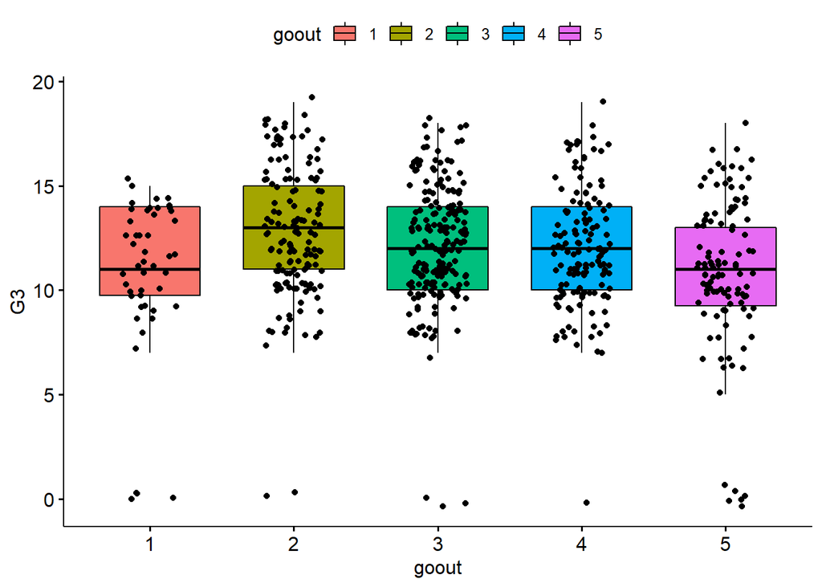

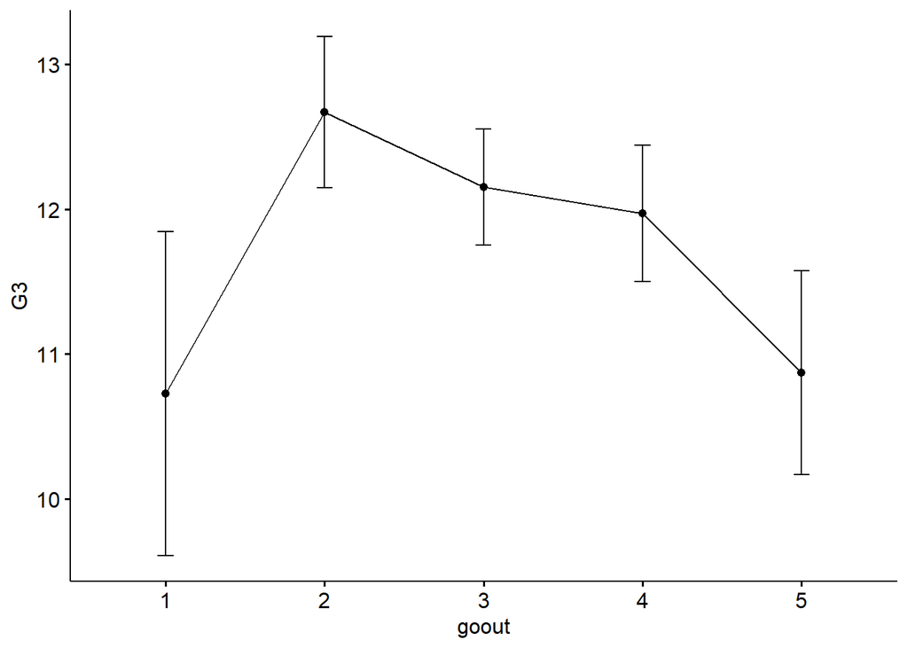

Dla grupy o poziomie 2 (mało czasu ze znajomymi) średnia oraz mediana punktów jest nieco wyższa niż dla pozozstałych grup. Na drugim wykresie widoczne różnice w średnich między poziomami “2”, “3” oraz “5”, oraz “1” i “2”.

Sprawdzamy założenia.

```
##   goout   n
## 1     1  48
## 2     2 145
## 3     3 205
## 4     4 141
## 5     5 110
```

Grupy są liczne. Można zatem sprawdzić założenie o normalności.

$H_0$: Rozkład cechy jest rozkładem normalnym.

$H_1$: Rozkład cechy nie jest rozkładem normalnym.

| goout | variable | statistic | p |
| --- | --- | --- | --- |
| 1 | G3 | 0.7852650 | 0.0000006 |
| 2 | G3 | 0.9432592 | 0.0000130 |
| 3 | G3 | 0.9304563 | 0.0000000 |
| 4 | G3 | 0.9597216 | 0.0003745 |
| 5 | G3 | 0.9122725 | 0.0000022 |

Dla wszystkich poziomów cechy `goout` odrzucamy hipotezę o normalności.

Sprawdzamy równość wariancji.

$H_0$: Wariancje w grupach są równe.

$H_1$: Wariancje w grupach nie są równe.

```
## Levene's Test for Homogeneity of Variance (center = median)
##        Df F value Pr(>F)
## group   4  1.3407 0.2533
##       644
```

Nie ma podstaw do odrzucenia hipotezy o równości wariancji w grupach.

Zostanie przeprowadzona ANOVA mimo braku spełnienia założenia o normalności.

```
##              Df Sum Sq Mean Sq F value   Pr(>F)
## goout         4    281   70.32   6.986 1.65e-05 ***
## Residuals   644   6482   10.07
## ---
## Signif. codes:  0 '***' 0.001 '**' 0.01 '*' 0.05 '.' 0.1 ' ' 1
```

Odrzucamy hipotezę, że wszystkie średnie są równe (nasza hipoteza zerowa to $\mu_1=\mu_2=\mu_3=\mu_4=\mu_5$ przy hipotezie alternatywnej, że istnieją $i,j∈\{1,2,3,4,5\}$, że $\mu_i≠\mu_j$).

```
##
## Study: mod_goout ~ "goout"
##
## LSD t Test for G3
## P value adjustment method: bonferroni
##
## Mean Square Error:  10.06523
##
## goout,  means and individual ( 95 %) CI
##
##         G3      std   r       LCL      UCL Min Max
## 1 10.72917 3.846743  48  9.829967 11.62837   0  15
## 2 12.66897 3.171170 145 12.151606 13.18633   0  19
## 3 12.15122 2.902258 205 11.716109 12.58633   0  18
## 4 11.97163 2.818164 141 11.446984 12.49628   0  19
## 5 10.87273 3.719794 110 10.278735 11.46672   0  18
##
## Alpha: 0.05 ; DF Error: 644
## Critical Value of t: 2.816741
##
## Groups according to probability of means differences and alpha level( 0.05 )
##
## Treatments with the same letter are not significantly different.
##
##         G3 groups
## 2 12.66897      a
## 3 12.15122      a
## 4 11.97163     ab
## 5 10.87273      b
## 1 10.72917      b
```

Test post-hoc LSD Fishera pokazuje istotne różnice uzyskiwanych punktów między grupami 1, 5 oraz grupami 2, 3.

- Będziemy badać zmienną `G3` w podziale ze względu na `Dalc` (spożywanie alkoholu w dni robocze o możliwych pięciu poziomach).

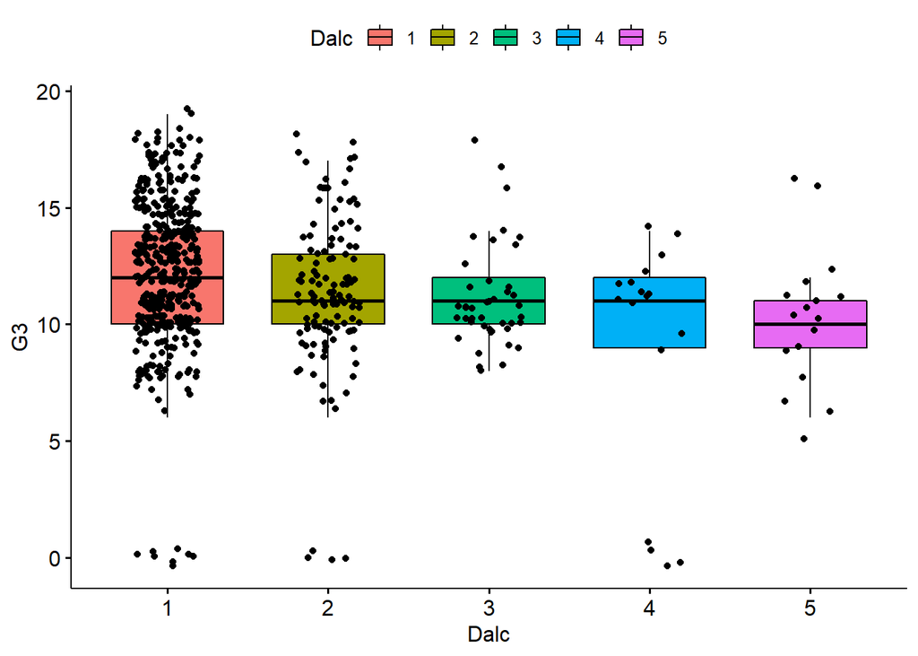

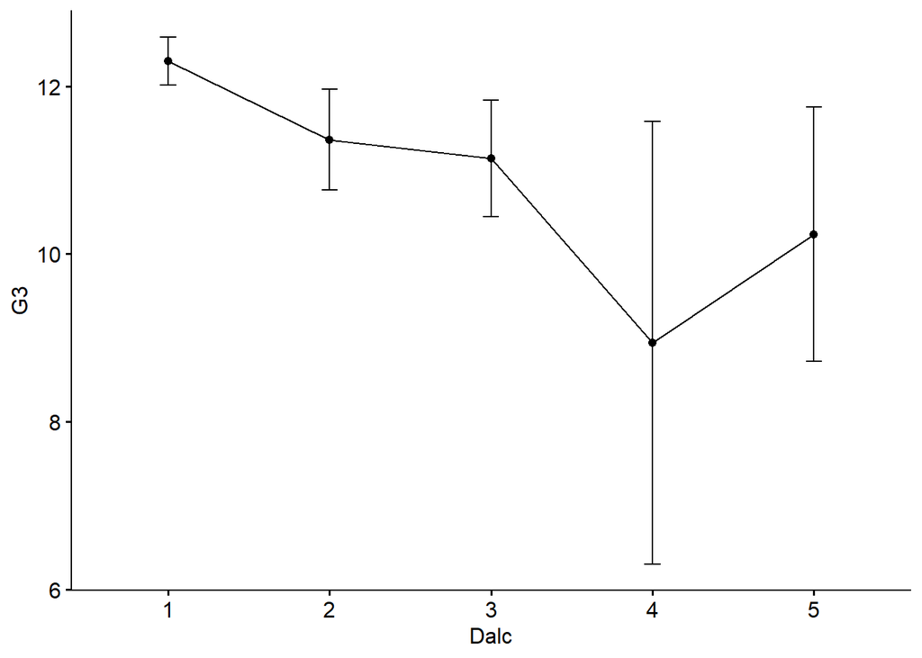

Zarówno mediana, jak i średnia punktów uczniów, w których domach spożywa się więcej alkoholu w dni robocze, jest nieco niższa. Widoczne różnice w średnich między grupą “1”, a pozostałymi grupami.

Sprawdzamy założenia.

```
##   Dalc   n
## 1    1 451
## 2    2 121
## 3    3  43
## 4    4  17
## 5    5  17
```

Grupy są liczne, choć dla poziomów “4” oraz “5” liczebności wynoszą po 17, co świadczy o niezbalansowaniu układu.

$H_0$: Rozkład cechy jest rozkładem normalnym.

$H_1$: Rozkład cechy nie jest rozkładem normalnym.

| Dalc | variable | statistic | p |
| --- | --- | --- | --- |
| 1 | G3 | 0.9345956 | 0.0000000 |
| 2 | G3 | 0.9132095 | 0.0000009 |
| 3 | G3 | 0.8685204 | 0.0001582 |
| 4 | G3 | 0.7443317 | 0.0003850 |
| 5 | G3 | 0.9409631 | 0.3297842 |

Dla poziomu 5 nie ma podstaw do odrzucenia o normalności. Dla pozostałych poziomów cechy `Dalc` odrzucamy hipotezę o normalności.

Sprawdzamy równość wariancji.

$H_0$: Wariancje w grupach są równe.

$H_1$: Wariancje w grupach nie są równe.

```
## Levene's Test for Homogeneity of Variance (center = median)
##        Df F value  Pr(>F)
## group   4  2.3219 0.05547 .
##       644
## ---
## Signif. codes:  0 '***' 0.001 '**' 0.01 '*' 0.05 '.' 0.1 ' ' 1
```

Nie ma podstaw do odrzucenia hipotezy o równości wariancji w grupach.

Przeprowadzimy analizę wariancji mimo braku spełnienia założenia o normalności ze względu na liczność badanych grup oraz odporność testu F na brak normalności efektu losowego.

```
##              Df Sum Sq Mean Sq F value  Pr(>F)
## Dalc          4    328   81.88   8.193 1.9e-06 ***
## Residuals   644   6436    9.99
## ---
## Signif. codes:  0 '***' 0.001 '**' 0.01 '*' 0.05 '.' 0.1 ' ' 1
```

Odrzucamy hipotezę, że wszystkie średnie są równe (hipoteza zerowa to $\mu_1=\mu_2=\mu_3=\mu_4=\mu_5$ przy hipotezie alternatywnej, że istnieją $i,j∈\{1,2,3,4,5\}$, że $\mu_i≠\mu_j$).

Wniosek: Spożywanie alkoholu w dni robocze powoduje istotne różnice w średniej punktów. Przeprowadzony zostanie test post-hoc aby sprawdzić różnice między średnimi w grupach.

```
##
## Study: mod_Dalc ~ "Dalc"
##
## LSD t Test for G3
## P value adjustment method: bonferroni
##
## Mean Square Error:  9.993405
##
## Dalc,  means and individual ( 95 %) CI
##
##          G3      std   r       LCL      UCL Min Max
## 1 12.299335 3.102898 451 12.007032 12.59164   0  19
## 2 11.363636 3.329164 121 10.799312 11.92796   0  18
## 3 11.139535 2.252844  43 10.192889 12.08618   8  18
## 4  8.941176 5.129213  17  7.435619 10.44673   0  14
## 5 10.235294 2.948080  17  8.729737 11.74085   5  16
##
## Alpha: 0.05 ; DF Error: 644
## Critical Value of t: 2.816741
##
## Groups according to probability of means differences and alpha level( 0.05 )
##
## Treatments with the same letter are not significantly different.
##
##          G3 groups
## 1 12.299335      a
## 2 11.363636      b
## 3 11.139535     bc
## 5 10.235294     bc
## 4  8.941176      c
```

Zauważyć można istotne różnice w średnich punktów między grupą uczniów, w których domach spożywa się alkohol w dni robocze na poziomie 1 (bardzo mało), a pozostałymi poziomami (od mało do bardzo dużo).

- Będziemy badać zmienną `G3` w podziale ze względu na `Walc` (ilość spożywanego alkoholu w weekendy o możliwych pięciu poziomach).

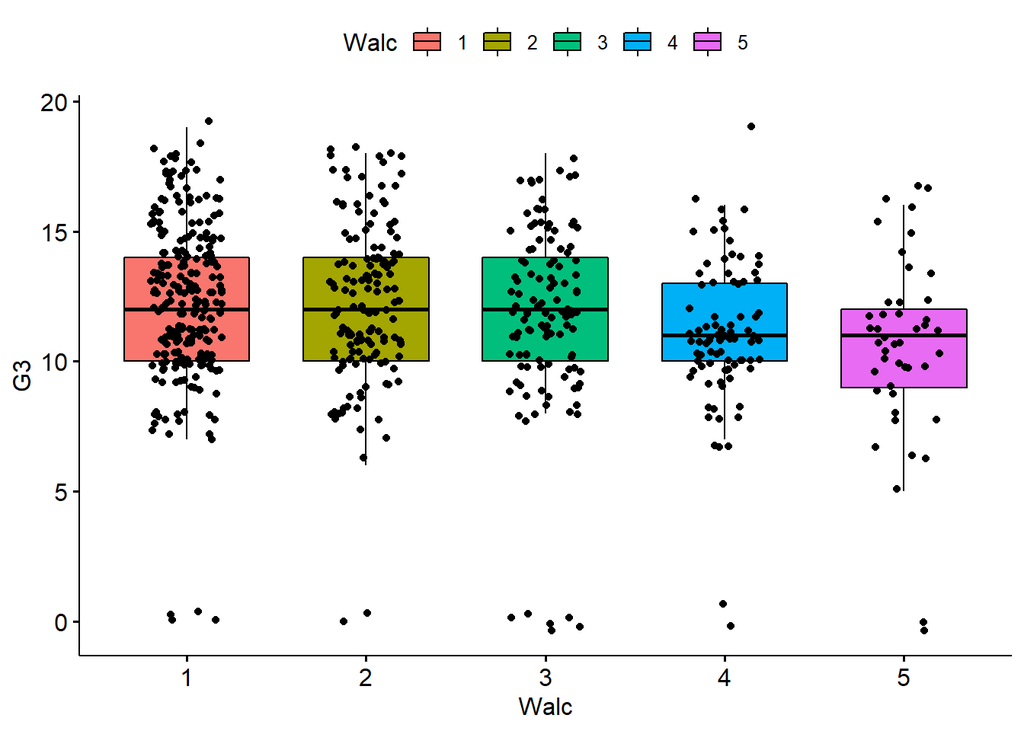

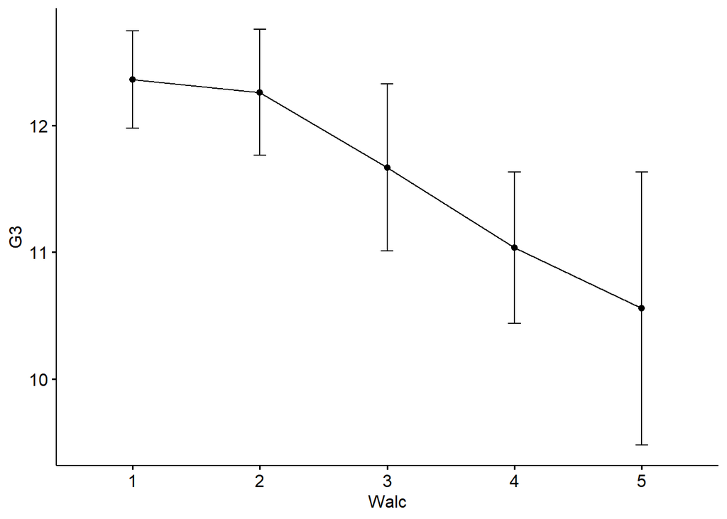

Widać niższe średnie w grupach uczniów, w których domach spożywa się więcej alkoholu w weekendy. Ponadto widać różnice w średnich punktów między poziomami “1”, “2” oraz “5”.

Sprawdzamy założenia.

```
##   Walc   n
## 1    1 247
## 2    2 150
## 3    3 120
## 4    4  87
## 5    5  45
```

Grupy są liczne. Można zatem sprawdzić założenie o normalności.

$H_0$: Rozkład cechy jest rozkładem normalnym.

$H_1$: Rozkład cechy nie jest rozkładem normalnym.

| Walc | variable | statistic | p |
| --- | --- | --- | --- |
| 1 | G3 | 0.9352720 | 0.0000000 |
| 2 | G3 | 0.9497269 | 0.0000311 |
| 3 | G3 | 0.8736661 | 0.0000000 |
| 4 | G3 | 0.9109859 | 0.0000176 |
| 5 | G3 | 0.9206338 | 0.0044424 |

Dla wszystkich poziomów cechy `Walc` odrzucamy hipotezę o normalności.

Sprawdzamy równość wariancji.

$H_0$: Wariancje w grupach są równe.

$H_1$: Wariancje w grupach nie są równe.

```
## Levene's Test for Homogeneity of Variance (center = median)
##        Df F value Pr(>F)
## group   4  1.1798 0.3184
##       644
```

Nie ma podstaw do odrzucenia hipotezy o równości wariancji w grupach.

Przeprowadzimy analizę wariancji mimo braku spełnienia założenia o normalności ze względu na liczność badanych grup oraz odporność testu F na brak normalności efektu losowego.

```
##              Df Sum Sq Mean Sq F value   Pr(>F)
## Walc          4    225   56.20   5.535 0.000219 ***
## Residuals   644   6538   10.15
## ---
## Signif. codes:  0 '***' 0.001 '**' 0.01 '*' 0.05 '.' 0.1 ' ' 1
```

Odrzucamy hipotezę, że wszystkie średnie są równe ($H_0$: $\mu_1=\mu_2=\mu_3=\mu_4=\mu_5$ przeciwko hipotezie alternatywnej, że istnieją $i,j∈\{1,2,3,4,5\}$, że $\mu_i≠\mu_j$).

```
##
## Study: mod_Walc ~ "Walc"
##
## LSD t Test for G3
## P value adjustment method: bonferroni
##
## Mean Square Error:  10.1529
##
## Walc,  means and individual ( 95 %) CI
##
##         G3      std   r      LCL      UCL Min Max
## 1 12.36032 3.057000 247 11.96221 12.75844   0  19
## 2 12.26000 3.085863 150 11.74913 12.77087   0  18
## 3 11.66667 3.642267 120 11.09549 12.23784   0  18
## 4 11.03448 2.805511  87 10.36367 11.70529   0  19
## 5 10.55556 3.583774  45  9.62283 11.48828   0  17
##
## Alpha: 0.05 ; DF Error: 644
## Critical Value of t: 2.816741
##
## Groups according to probability of means differences and alpha level( 0.05 )
##
## Treatments with the same letter are not significantly different.
##
##         G3 groups
## 1 12.36032      a
## 2 12.26000      a
## 3 11.66667     ab
## 4 11.03448      b
## 5 10.55556      b
```

Zauważyć można różnice w średnich punktach między grupą uczniów, w których domach spożywa się alkohol w weekendy na poziomie 1 i 2 (bardzo mało oraz mało), a poziomami 4 i 5 (dużo i bardzo dużo), co potwierdza wcześniejsze przypuszczenia.

## Wnioski

Ilość punktów końcowych uczniów zależy od:

- adresu zamieszkania ucznia

Uczniowie mieszkający w mieście otrzymywali wyższe ilości punktów na koniec roku.

- poziomu edukacji matki

Mediana oraz zakres zdobywanych punktów wzrasta wraz z wyższym poziomem edukacji matki. W przypadku grupy uczniów, których matki mają wykształcenie wyższe, uzyskują oni wyższe ilości punktów niż pozostałe grupy.

- poziomu edukacji ojca

- tygodniowej ilości nauki

- chęci kontynuowania edukacji

Średnia uzyskiwanych punktów końcowych uczniów, którzy zamierzają kontynuować edukację, jest wyższa od średniej grupy uczniów, którzy swojej edukacji nie zamierzają kontynuować.

- ilości czasu wolnego

- ilości czasu przeznaczonej na spotkania ze znajomymi

- ilości spożywanego alkoholu w dni robocze

Uczniowie, w których domach spożywa się duże ilości alkoholu uzyskują dużo niższe punkty.

- ilości spożywanego alkoholu w weekendy

Wyższe średnie punktów końcowych z przedmiotu występują u uczniów, w których domach ilość spożywanego alkoholu w weekendy jest bardzo mała oraz mała.